# Alive Survivorship Over Time (Replicate-Level)

Sarai Hutchinson

2025-08-26

```r
library(tidyverse)
library(viridis)

# Color palettes
okabe_ito <- c("#009E73", "#D55E00", "#E69F00", "#56B4E9", "#F0E442", "#0072B2", "#CC79A7")
viridis_palette <- viridis(8)

# Read data
ALLDATA <- read_csv("C:\\Users\\sarai\\OneDrive\\Email attachments\\Documents\\UVI\\Thesis.Work\\SargMangs\\Data/Hutchinson_MonthlyMonitoring-MASTER3.csv")

# Inspect structure (optional)
# str(ALLDATA)

# Clean treatment labels (ordered for legend)
ALLDATA <- ALLDATA %>%
  mutate(
    Treatment_Name = case_when(
      Treatment == "A" ~ "Soil",
      Treatment == "B" ~ "Crushed glass (CG)",
      Treatment == "C" ~ "Sargassum only (SG)",
      Treatment == "D" ~ "3:1 CG to SG",
      Treatment == "E" ~ "1:3 CG to SG",
      TRUE ~ as.character(Treatment)
    ),
    Treatment_Name = factor(
      Treatment_Name,
      levels = c("Soil", "Crushed glass (CG)", "Sargassum only (SG)", "1:3 CG to SG", "3:1 CG to SG")
    )
  )
```

## Creating list with the ALLDATA at tp1 and tp6

```r
# Step 1: Filter to Alive plants in Time_Period 1 or 6
alive_tp1_6 <- ALLDATA %>%
  filter(Time_Period %in% c(1, 6), Survivorship == "A")


unique(ALLDATA$Time_Period)
```

```
## [1] 1 2 3 4 5 6
```

```r
unique(ALLDATA$Survivorship)
```

```
## [1] "A"  "D"  "DY"
```

```r
# Step 2: Keep only Prop_IDs that are alive in BOTH time periods
survived_both <- alive_tp1_6 %>%
  group_by(Prop_ID) %>%
  filter(n_distinct(Time_Period) == 2) %>%  # Ensures alive in both 1 and 6
  ungroup()

# Step 3: Create separate lists for RHMA and LARA
RHMA_survivors <- survived_both %>%
  filter(Species == "RHMA") %>%
  select(Prop_ID) %>%
  distinct()

LARA_survivors <- survived_both %>%
  filter(Species == "LARA") %>%
  select(Prop_ID) %>%
  distinct()

# Step 4 (optional): If you want to save or view them in one long dataframe with a species label
final_long_list <- bind_rows(
  RHMA_survivors %>% mutate(Species = "RHMA"),
  LARA_survivors %>% mutate(Species = "LARA")
)

# View final output
print(final_long_list)
```

```
## # A tibble: 336 × 2
##    Prop_ID Species
##    <chr>   <chr>
##  1 RE-14   RHMA
##  2 RE-31   RHMA
##  3 RE-32   RHMA
##  4 RE-33   RHMA
##  5 RE-12   RHMA
##  6 RE-52   RHMA
##  7 RE-3    RHMA
##  8 RE-44   RHMA
##  9 RE-1    RHMA
## 10 RE-45   RHMA
## # ℹ 326 more rows
```

```r
##This part gives me a list with both instead of separated.

# Step 1: Filter to Alive plants in Time_Period 1 or 6
alive_tp1_6 <- ALLDATA %>%
  filter(Time_Period %in% c(1, 6), Survivorship == "A")

# Step 2: Identify Prop_IDs that survived both TP 1 AND TP 6
survivor_ids <- alive_tp1_6 %>%
  group_by(Prop_ID) %>%
  filter(n_distinct(Time_Period) == 2) %>%
  pull(Prop_ID) %>%
  unique()

# Step 3: Pull all rows (all time periods) for just those Prop_IDs
survivor_full_history <- ALLDATA %>%
  filter(Prop_ID %in% survivor_ids)

# View or use
print(survivor_full_history)
```

```
## # A tibble: 2,019 × 29
##    Data_Uploaded Date_Uploaded Monitored_By Date_Monitored Location Replicate
##    <chr>         <chr>         <chr>        <chr>             <dbl>     <dbl>
##  1 SH            12/08/2024    ZG, SH       12/02/2024            1         3
##  2 SH            12/08/2024    ZG, SH       12/02/2024            1         3
##  3 SH            12/08/2024    ZG, SH       12/02/2024            1         3
##  4 SH            12/08/2024    ZG, SH       12/02/2024            1         3
##  5 SH            12/08/2024    ZG, SH       12/02/2024            1         3
##  6 SH            12/08/2024    ZG, SH       12/02/2024            1         3
##  7 SH            12/08/2024    ZG, SH       12/02/2024            1         3
##  8 SH            12/08/2024    ZG, SH       12/02/2024            1         3
##  9 SH            12/08/2024    ZG, SH       12/02/2024            1         3
## 10 SH            12/08/2024    ZG, SH       12/02/2024            1         3
## # ℹ 2,009 more rows
## # ℹ 23 more variables: Species <chr>, Treatment <chr>, Prop_ID <chr>,
## #   Time_Period <dbl>, Survivorship <chr>, Condition <chr>, Pests <chr>,
## #   Leaf_Color <chr>, RHMA_Height_1 <chr>, RHMA_Height_2 <chr>,
## #   RHMA_Epi_Length <chr>, LARA_Height_1 <chr>, LARA_Height_2 <chr>,
## #   Number_Branches <chr>, Leaves_Main <chr>, Leaves_Branches <chr>,
## #   Total_Leaves <chr>, Nodes_Main <chr>, Nodes_Branches <chr>, …
```

```r
# Export the full dataset of ALLDATA (all time periods) to CSV
write.csv(survivor_full_history, "survivors_tp1_to_tp6.csv", row.names = FALSE)
```

## Method

We calculate **percent Alive per replicate** at each monitoring period, then visualize the replicate trajectories over time. Alive is coded as `"A"` (DY and D are not counted as alive here).

```r
# Replicate-level % Alive (A only)
rep_alive <- ALLDATA %>%
  group_by(Species, Treatment_Name, Replicate, Time_Period) %>%
  summarise(
    alive_n = sum(Survivorship == "A", na.rm = TRUE),
    total_n = n(),
    alive_pct = (alive_n / total_n) * 100,
    .groups = "drop"
  )

# Order/label Time_Period for plotting
if (is.character(rep_alive$Time_Period)) {
  maybe_num <- readr::parse_number(rep_alive$Time_Period)
  if (all(!is.na(maybe_num))) {
    rep_alive <- rep_alive %>% mutate(Time_Period_num = maybe_num)
  } else {
    rep_alive <- rep_alive %>%
      mutate(Time_Period_num = as.numeric(factor(Time_Period, levels = unique(Time_Period))))
  }
} else {
  rep_alive <- rep_alive %>% mutate(Time_Period_num = as.numeric(Time_Period))
}

alive_summary <- rep_alive %>%
  dplyr::group_by(Species, Treatment_Name, Time_Period_num) %>%
  dplyr::summarise(
    mean_alive = mean(alive_pct, na.rm = TRUE),
    sd_alive   = sd(alive_pct,   na.rm = TRUE),
    .groups = "drop"
  )
```

```r
# Replicate-level counts of ALIVE (A only)
rep_alive_counts <- ALLDATA %>%
  dplyr::group_by(Species, Treatment_Name, Replicate, Time_Period) %>%
  dplyr::summarise(
    alive_n = sum(Survivorship == "A", na.rm = TRUE),
    .groups = "drop"
  )

# Order Time_Period for plotting
rep_alive_counts <- rep_alive_counts %>%
  dplyr::mutate(
    Time_Period_num = if (is.character(Time_Period)) {
      maybe_num <- readr::parse_number(Time_Period)
      ifelse(is.na(maybe_num),
             as.numeric(factor(Time_Period, levels = unique(Time_Period))),
             maybe_num)
    } else {
      as.numeric(Time_Period)
    }
  )

# Treatment MEAN counts across replicates per time point
alive_count_summary <- rep_alive_counts %>%
  dplyr::group_by(Species, Treatment_Name, Time_Period_num) %>%
  dplyr::summarise(
    mean_alive_n = mean(alive_n, na.rm = TRUE),
    sd_alive_n   = sd(alive_n,   na.rm = TRUE),
    n_reps       = dplyr::n(),
    .groups = "drop"
  )
```

```r
##Create a dataframe with the intake information of those that survived

#Import LARA and RHMA data
LARA_Intake <- read_csv("C:\\Users\\sarai\\OneDrive\\Email attachments\\Documents\\UVI\\Thesis.Work\\SargMangs\\Data/LARA_IntakeData.csv")
RHMA_Intake <- read_csv("C:\\Users\\sarai\\OneDrive\\Email attachments\\Documents\\UVI\\Thesis.Work\\SargMangs\\Data/RHMA_IntakeData.csv")
```

```r
# Step 1: Get list of Prop_IDs that survived at Time_Period 6
survivors_tp6 <- survivor_full_history %>%
  filter(Time_Period == 6) %>%
  pull(Prop_ID) %>%
  unique()

print(survivors_tp6)
```

```
##   [1] "RB-32" "RB-12" "RB-31" "RB-53" "RB-11" "RB-54" "RB-34" "RB-55" "RB-51"
##  [10] "RB-33" "RB-14" "RB-52" "RB-15" "RB-35" "LB-55" "LB-51" "LB-53" "LB-54"
##  [19] "LB-14" "RA-34" "RA-31" "RA-55" "RA-13" "RA-52" "RA-12" "RA-11" "RA-33"
##  [28] "RA-14" "RA-53" "RA-32" "RA-51" "RA-35" "RA-54" "RA-15" "LA-14" "LA-33"
##  [37] "LA-53" "LA-32" "LA-31" "LA-34" "LA-54" "LA-35" "LA-15" "RA-40" "RA-36"
##  [46] "RA-39" "RA-57" "RA-17" "RA-37" "RA-58" "RA-59" "RA-18" "RA-38" "RA-60"
##  [55] "RA-20" "RA-16" "RA-19" "RA-56" "LA-16" "LA-40" "LA-20" "LA-58" "LA-18"
##  [64] "LA-19" "LA-56" "LA-57" "LA-37" "LA-17" "LA-59" "LA-60" "RA-24" "RA-45"
##  [73] "RA-21" "RA-2"  "RA-4"  "RA-3"  "RA-41" "RA-1"  "RA-43" "RA-23" "RA-22"
##  [82] "RA-44" "RA-25" "RA-42" "LA-25" "LA-45" "LA-41" "LA-43" "RC-38" "RC-20"
##  [91] "RC-58" "RC-39" "RC-19" "RC-18" "RC-56" "RC-36" "RC-60" "RC-37" "RC-59"
## [100] "RC-16" "LC-20" "RC-12" "RC-11" "RC-52" "RC-51" "RC-31" "RC-35" "RC-32"
## [109] "RC-14" "RC-15" "RC-53" "RC-54" "RC-55" "RD-46" "RD-47" "RD-7"  "RD-26"
## [118] "RD-49" "RD-29" "RD-28" "RD-6"  "RD-10" "RD-48" "RD-30" "RD-8"  "RD-50"
## [127] "RD-27" "RD-9"  "RE-25" "RE-45" "RE-1"  "RE-5"  "RE-2"  "RE-44" "RE-24"
```

[output cut: 23 more lines]

```r
# Step 2: Filter intake data for only those ALLDATA
# Filter LARA intake data
intake_lara_survivors <- LARA_Intake %>%
  filter(Prop_ID %in% survivors_tp6)

# Filter RHMA intake data
intake_rhma_survivors <- RHMA_Intake %>%
  filter(Prop_ID %in% survivors_tp6)

# Combine both sets of ALLDATA while preserving all columns
combined_intake_survivors <- full_join(intake_lara_survivors, intake_rhma_survivors, by = intersect(names(intake_lara_survivors), names(intake_rhma_survivors)))

# Remove the Prop_ID column
combined_intake_survivors <- combined_intake_survivors %>%
  select(-Prop_ID)






# # Which rows are in RHMA_survivors but not in intake_rhma_survivors
# anti_join(RHMA_survivors, intake_rhma_survivors, by = "Prop_ID")


##oF THOSE THAT SURVIVED, HOW MANY ARE FROM A PARTICULAR SITE if there are 3 sites for each species and 100 plants per site?

# Count number of ALLDATA per site
site_counts <- combined_intake_survivors %>%
  group_by(Species, Site) %>%
  summarise(
    Num_Survived = n()
  ) %>%
  arrange(Species, Site)
print(site_counts)
```

```
## # A tibble: 6 × 3
## # Groups:   Species [2]
##   Species Site  Num_Survived
##   <chr>   <chr>        <int>
## 1 LARA    MB              23
## 2 LARA    PR              31
## 3 LARA    VB              20
## 4 RHMA    CP              88
## 5 RHMA    OC              87
## 6 RHMA    PR              87
```

```r
site_counts <- site_counts %>%
  mutate(Survival_Rate = Num_Survived / 100 * 100)  # Since 100 planted per site

print(site_counts)
```

```
## # A tibble: 6 × 4
## # Groups:   Species [2]
##   Species Site  Num_Survived Survival_Rate
##   <chr>   <chr>        <int>         <dbl>
## 1 LARA    MB              23            23
## 2 LARA    PR              31            31
## 3 LARA    VB              20            20
## 4 RHMA    CP              88            88
## 5 RHMA    OC              87            87
## 6 RHMA    PR              87            87
```

```r
#Combine ALLDATA dataframe with Site column from intake dataframes
# Keep only Prop_ID and Site from intake files
lara_sites <- LARA_Intake %>%
  select(Prop_ID, Site)

rhma_sites <- RHMA_Intake %>%
  select(Prop_ID, Site)

# Combine both into one Site lookup table
site_lookup <- bind_rows(lara_sites, rhma_sites)

# Add the Site column to ALLDATA by joining on Prop_ID
ALLDATA_with_site <- ALLDATA %>%
  left_join(site_lookup, by = "Prop_ID")

# Step 1: Clean and Prepare Data
survivors_clean2 <- ALLDATA_with_site %>%
  mutate(
    Surv_Bin = ifelse(Survivorship %in% c("A", "DY"), 1, 0),
    Treatment = case_when(
      Treatment == "A" ~ "Soil",
      Treatment == "B" ~ "Crushed glass (CG)",
      Treatment == "C" ~ "Sargassum only (SG)",
      Treatment == "D" ~ "3:1 CG to SG",
      Treatment == "E" ~ "1:3 CG to SG",
      TRUE ~ as.character(Treatment)
    ),
    Treatment = factor(Treatment, levels = c("Soil", "Crushed glass (CG)", "Sargassum only (SG)", "3:1 CG to SG", "1:3 CG to SG")),
    Time_Period = factor(Time_Period, levels = c("1", "2", "3", "4", "5", "6")),
    Species = factor(Species)
  )

# Create dataframe for LARA
LARA_data <- survivors_clean2 %>%
  filter(Species == "LARA")

# Create dataframe for RHMA
RHMA_data <- survivors_clean2 %>%
  filter(Species == "RHMA")

##Doing this to see if the survival is impacted by their collection site
# Logistic regression: Survival ~ Site
glm_site_LARA <- glm(Surv_Bin ~ Site, data = LARA_data, family = binomial)
summary(glm_site_LARA)
```

```
##
## Call:
## glm(formula = Surv_Bin ~ Site, family = binomial, data = LARA_data)
##
## Coefficients:
##             Estimate Std. Error z value Pr(>|z|)
## (Intercept) -0.67567    0.08643  -7.818 5.37e-15 ***
## SitePR       0.58576    0.11891   4.926 8.38e-07 ***
## SiteVB      -0.35305    0.12673  -2.786  0.00534 **
## ---
## Signif. codes:  0 '***' 0.001 '**' 0.01 '*' 0.05 '.' 0.1 ' ' 1
##
## (Dispersion parameter for binomial family taken to be 1)
##
##     Null deviance: 2351.2  on 1799  degrees of freedom
## Residual deviance: 2289.5  on 1797  degrees of freedom
## AIC: 2295.5
##
## Number of Fisher Scoring iterations: 4
```

```r
glm_site_RHMA <- glm(Surv_Bin ~ Site, data = RHMA_data, family = binomial)
summary(glm_site_RHMA)
```

```
##
## Call:
## glm(formula = Surv_Bin ~ Site, family = binomial, data = RHMA_data)
##
## Coefficients:
##             Estimate Std. Error z value Pr(>|z|)
## (Intercept)   2.7815     0.1742  15.968   <2e-16 ***
## SiteOC        0.3096     0.2656   1.166   0.2438
## SitePR       -0.4437     0.2259  -1.964   0.0495 *
## ---
## Signif. codes:  0 '***' 0.001 '**' 0.01 '*' 0.05 '.' 0.1 ' ' 1
##
## (Dispersion parameter for binomial family taken to be 1)
##
##     Null deviance: 849.75  on 1799  degrees of freedom
## Residual deviance: 839.49  on 1797  degrees of freedom
## AIC: 845.49
##
## Number of Fisher Scoring iterations: 5
```

```r
library(ggplot2)
library(ggeffects)

# Plot the predicted survival probabilities with CI for LARA
lara_pred <- ggpredict(glm_site_LARA, terms = "Site")
```

```
## Some of the focal terms are of type `character`. This may lead to
##   unexpected results. It is recommended to convert these variables to
##   factors before fitting the model.
##   The following variables are of type character: `Site`
```

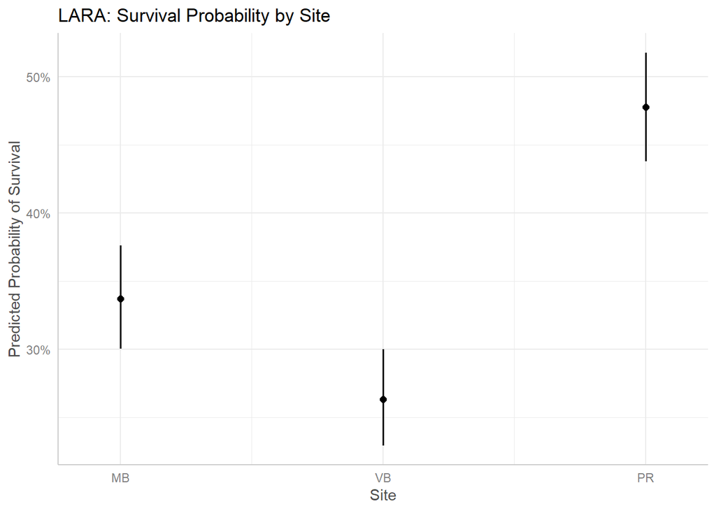

```r
plot(lara_pred) +
  ggtitle("LARA: Survival Probability by Site") +
  ylab("Predicted Probability of Survival")
```

```r
# Predicted survival probabilities with CI for RHMA
rhma_pred <- ggpredict(glm_site_RHMA, terms = "Site")
```

```
## Some of the focal terms are of type `character`. This may lead to
##   unexpected results. It is recommended to convert these variables to
##   factors before fitting the model.
##   The following variables are of type character: `Site`
```

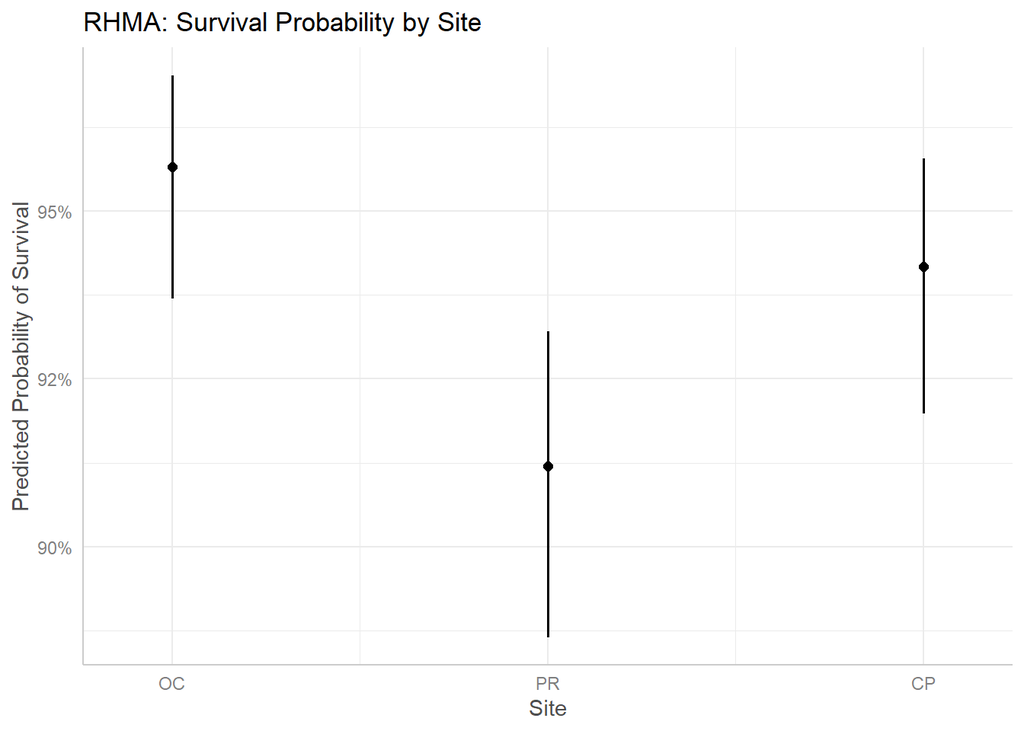

```r
plot(rhma_pred) +
  ggtitle("RHMA: Survival Probability by Site") +
  ylab("Predicted Probability of Survival")
```

```r
library(lme4)
#Refit Models with Interaction: Site * Treatment + (1 | Replicate)
# For LARA
glmm_LARA <- glmer(Surv_Bin ~ Site * Treatment + (1 | Replicate),
                   data = LARA_data, family = binomial)
summary(glmm_LARA)
```

```
## Generalized linear mixed model fit by maximum likelihood (Laplace
##   Approximation) [glmerMod]
##  Family: binomial  ( logit )
## Formula: Surv_Bin ~ Site * Treatment + (1 | Replicate)
##    Data: LARA_data
##
##       AIC       BIC    logLik -2*log(L)  df.resid
##    1964.0    2051.9    -966.0    1932.0      1784
##
## Scaled residuals:
##     Min      1Q  Median      3Q     Max
## -3.2468 -0.6236 -0.3963  0.7526  4.0203
##
## Random effects:
##  Groups    Name        Variance Std.Dev.
##  Replicate (Intercept) 0.3055   0.5527
## Number of obs: 1800, groups:  Replicate, 4
##
## Fixed effects:
##                                     Estimate Std. Error z value Pr(>|z|)
## (Intercept)                           0.5067     0.3381   1.499 0.133922
## SitePR                                1.2039     0.3178   3.789 0.000151 ***
## SiteVB                               -0.5830     0.2716  -2.146 0.031848 *
## TreatmentCrushed glass (CG)          -1.7766     0.2953  -6.016 1.79e-09 ***
## TreatmentSargassum only (SG)         -2.2057     0.3176  -6.945 3.77e-12 ***
## Treatment3:1 CG to SG                -0.6188     0.2717  -2.277 0.022767 *
## Treatment1:3 CG to SG                -2.0373     0.3074  -6.628 3.39e-11 ***
## SitePR:TreatmentCrushed glass (CG)    0.6877     0.4342   1.584 0.113224
## SiteVB:TreatmentCrushed glass (CG)    0.7246     0.4103   1.766 0.077361 .
## SitePR:TreatmentSargassum only (SG)  -0.5435     0.4551  -1.194 0.232391
## SiteVB:TreatmentSargassum only (SG)   0.2957     0.4583   0.645 0.518849
## SitePR:Treatment3:1 CG to SG         -1.2399     0.4157  -2.983 0.002857 **
## SiteVB:Treatment3:1 CG to SG         -0.3879     0.3930  -0.987 0.323681
## SitePR:Treatment1:3 CG to SG         -1.3357     0.4655  -2.869 0.004113 **
## SiteVB:Treatment1:3 CG to SG          0.4834     0.4355   1.110 0.266992
## ---
## Signif. codes:  0 '***' 0.001 '**' 0.01 '*' 0.05 '.' 0.1 ' ' 1
```

```
##
## Correlation matrix not shown by default, as p = 15 > 12.
## Use print(x, correlation=TRUE)  or
##     vcov(x)        if you need it
```

```r
# For RHMA
glmm_RHMA <- glmer(Surv_Bin ~ Site * Treatment + (1 | Replicate),
                   data = RHMA_data, family = binomial)
summary(glmm_RHMA)
```

```
## Generalized linear mixed model fit by maximum likelihood (Laplace
##   Approximation) [glmerMod]
##  Family: binomial  ( logit )
## Formula: Surv_Bin ~ Site * Treatment + (1 | Replicate)
##    Data: RHMA_data
##
##       AIC       BIC    logLik -2*log(L)  df.resid
##     613.1     701.1    -290.6     581.1      1784
##
## Scaled residuals:
##      Min       1Q   Median       3Q      Max
## -12.5857   0.0000   0.0000   0.2673   0.9382
##
## Random effects:
##  Groups    Name        Variance Std.Dev.
##  Replicate (Intercept) 1.585    1.259
## Number of obs: 1800, groups:  Replicate, 4
##
## Fixed effects:
##                                       Estimate Std. Error z value Pr(>|z|)
## (Intercept)                          2.196e+01  4.226e+03   0.005    0.996
## SiteOC                              -9.905e-03  5.974e+03   0.000    1.000
## SitePR                              -7.817e-03  5.953e+03   0.000    1.000
## TreatmentCrushed glass (CG)          7.772e-01  7.531e+03   0.000    1.000
## TreatmentSargassum only (SG)        -1.988e+01  4.226e+03  -0.005    0.996
## Treatment3:1 CG to SG                1.534e-02  6.000e+03   0.000    1.000
## Treatment1:3 CG to SG               -1.968e+01  4.226e+03  -0.005    0.996
## SiteOC:TreatmentCrushed glass (CG)  -2.586e-02  1.060e+04   0.000    1.000
## SitePR:TreatmentCrushed glass (CG)   6.555e-01  1.216e+04   0.000    1.000
## SiteOC:TreatmentSargassum only (SG)  1.024e+00  5.974e+03   0.000    1.000
## SitePR:TreatmentSargassum only (SG)  4.709e-01  5.953e+03   0.000    1.000
## SiteOC:Treatment3:1 CG to SG         2.999e-01  8.836e+03   0.000    1.000
## SitePR:Treatment3:1 CG to SG        -1.837e+01  7.320e+03  -0.003    0.998
## SiteOC:Treatment1:3 CG to SG        -1.266e-01  5.974e+03   0.000    1.000
## SitePR:Treatment1:3 CG to SG        -1.061e+00  5.953e+03   0.000    1.000
```

```
##
## Correlation matrix not shown by default, as p = 15 > 12.
## Use print(x, correlation=TRUE)  or
##     vcov(x)        if you need it
```

```
## optimizer (Nelder_Mead) convergence code: 0 (OK)
## unable to evaluate scaled gradient
## Model failed to converge: degenerate  Hessian with 2 negative eigenvalues
```

```r
library(sjPlot)

#Add Confidence Intervals to Fixed Effects (Odds Ratios)
tab_model(glmm_LARA,
          transform = "exp",  # to show odds ratios
          show.ci = TRUE,
          show.p = TRUE,
          show.se = TRUE,
          title = "LARA: Logistic Mixed Model with Site x Treatment Interaction")
```

LARA: Logistic Mixed Model with Site x Treatment Interaction

|  | Surv Bin |  |  |  |
| --- | --- | --- | --- | --- |
| Predictors | Odds Ratios | std. Error | CI | p |
| (Intercept) | 1.66 | 0.56 | 0.00 – Inf | 0.134 |
| Site [PR] | 3.33 | 1.06 | 0.00 – Inf | **<0.001** |
| Site [VB] | 0.56 | 0.15 | 0.00 – Inf | **0.032** |
| Treatment [Crushed glass (CG)] | 0.17 | 0.05 | 0.00 – Inf | **<0.001** |
| Treatment [Sargassum only (SG)] | 0.11 | 0.03 | 0.00 – Inf | **<0.001** |
| Treatment3 × 1 CG to SG | 0.54 | 0.15 | 0.00 – Inf | **0.023** |
| Treatment1 × 3 CG to SG | 0.13 | 0.04 | 0.00 – Inf | **<0.001** |
| Site [PR] × Treatment [Crushed glass (CG)] | 1.99 | 0.86 | 0.00 – Inf | 0.113 |
| Site [VB] × Treatment [Crushed glass (CG)] | 2.06 | 0.85 | 0.00 – Inf | 0.077 |
| Site [PR] × Treatment [Sargassum only (SG)] | 0.58 | 0.26 | 0.00 – Inf | 0.232 |
| Site [VB] × Treatment [Sargassum only (SG)] | 1.34 | 0.62 | 0.00 – Inf | 0.519 |
| Site [PR] × Treatment3 × 1 CG to SG | 0.29 | 0.12 | 0.00 – Inf | **0.003** |
| Site [VB] × Treatment3 × 1 CG to SG | 0.68 | 0.27 | 0.00 – Inf | 0.324 |
| Site [PR] × Treatment1 × 3 CG to SG | 0.26 | 0.12 | 0.00 – Inf | **0.004** |
| Site [VB] × Treatment1 × 3 CG to SG | 1.62 | 0.71 | 0.00 – Inf | 0.267 |
| Random Effects |  |  |  |  |
| σ<sup>2</sup> | 3.29 |  |  |  |
| τ<sub>00</sub> <sub>Replicate</sub> | 0.31 |  |  |  |
| ICC | 0.08 |  |  |  |
| N <sub>Replicate</sub> | 4 |  |  |  |
| Observations | 1800 |  |  |  |
| Marginal R<sup>2</sup> / Conditional R<sup>2</sup> | 0.228 / 0.294 |  |  |  |

```r
###PLEASE NOTE: I love the APA-style table this created! I might use this to display my other results in supplementals.

#Visualise the things now

# Create predictions across Site and Treatment
pred_lara <- ggpredict(glmm_LARA, terms = c("Treatment", "Site"))
```

```
## You are calculating adjusted predictions on the population-level (i.e.
##   `type = "fixed"`) for a *generalized* linear mixed model.
##   This may produce biased estimates due to Jensen's inequality. Consider
##   setting `bias_correction = TRUE` to correct for this bias.
##   See also the documentation of the `bias_correction` argument.
```

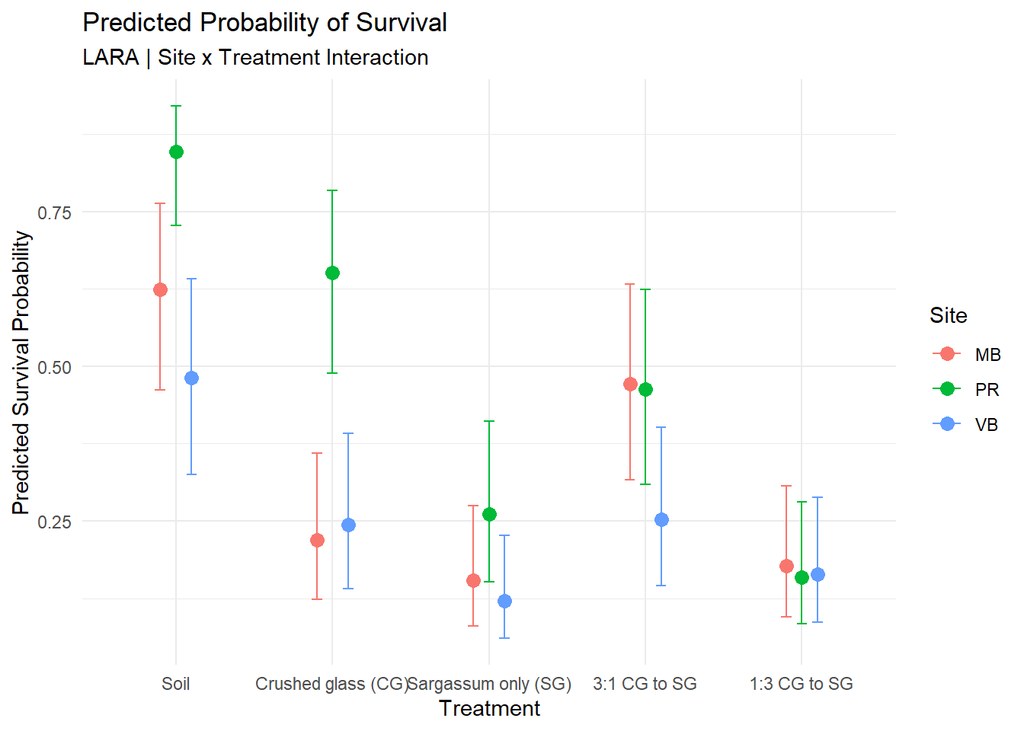

```r
# Plot
ggplot(pred_lara, aes(x = x, y = predicted, color = group)) +
  geom_point(position = position_dodge(0.3), size = 3) +
  geom_errorbar(aes(ymin = conf.low, ymax = conf.high),
                position = position_dodge(0.3), width = 0.2) +
  labs(
    title = "Predicted Probability of Survival",
    subtitle = "LARA | Site x Treatment Interaction",
    x = "Treatment", y = "Predicted Survival Probability",
    color = "Site"
  ) +
  theme_minimal()
```

```r
#The RHMA version of the glmm didn't work and this one didn't either
glmm_RHMA_simple <- glmer(Surv_Bin ~ Site + Treatment + (1 | Replicate),
                          data = RHMA_data, family = binomial)
summary(glmm_RHMA_simple)
```

```
## Generalized linear mixed model fit by maximum likelihood (Laplace
##   Approximation) [glmerMod]
##  Family: binomial  ( logit )
## Formula: Surv_Bin ~ Site + Treatment + (1 | Replicate)
##    Data: RHMA_data
##
##       AIC       BIC    logLik -2*log(L)  df.resid
##     613.5     657.5    -298.8     597.5      1792
##
## Scaled residuals:
##      Min       1Q   Median       3Q      Max
## -11.7913   0.0000   0.0433   0.1974   0.8612
##
## Random effects:
##  Groups    Name        Variance Std.Dev.
##  Replicate (Intercept) 1.561    1.249
## Number of obs: 1800, groups:  Replicate, 4
##
## Fixed effects:
##                               Estimate Std. Error z value Pr(>|z|)
## (Intercept)                    22.0630  2412.4272   0.009   0.9927
## SiteOC                          0.3648     0.2839   1.285   0.1989
## SitePR                         -0.5384     0.2484  -2.167   0.0302 *
## TreatmentCrushed glass (CG)     1.1263  4874.8896   0.000   0.9998
## TreatmentSargassum only (SG)  -19.4503  2412.4271  -0.008   0.9936
## Treatment3:1 CG to SG         -17.2037  2412.4271  -0.007   0.9943
## Treatment1:3 CG to SG         -20.1504  2412.4271  -0.008   0.9933
## ---
## Signif. codes:  0 '***' 0.001 '**' 0.01 '*' 0.05 '.' 0.1 ' ' 1
##
## Correlation of Fixed Effects:
##             (Intr) SiteOC SitePR TCg(CG TSo(SG T3:CtS
## SiteOC       0.000
## SitePR       0.000  0.502
## TrtmnCg(CG) -0.495  0.000  0.000
## TrtmnSo(SG) -1.000  0.000  0.000  0.495
## Trt3:1CGtSG -1.000  0.000  0.000  0.495  1.000
## Trt1:3CGtSG -1.000  0.000  0.000  0.495  1.000  1.000
## optimizer (Nelder_Mead) convergence code: 0 (OK)
## unable to evaluate scaled gradient
## Model failed to converge: degenerate  Hessian with 1 negative eigenvalues
```

```r
##NEXT STEPS
#I need to just get the mean overall height by species and any propagule differences upon intake
```

## Plot A — Per-treatment panels (replicate “spaghetti” lines)

Each panel is a treatment; lines are **replicates**; facets by **Species** (rows) and **Treatment** (columns). This is best to see replicate variability *within* each treatment.

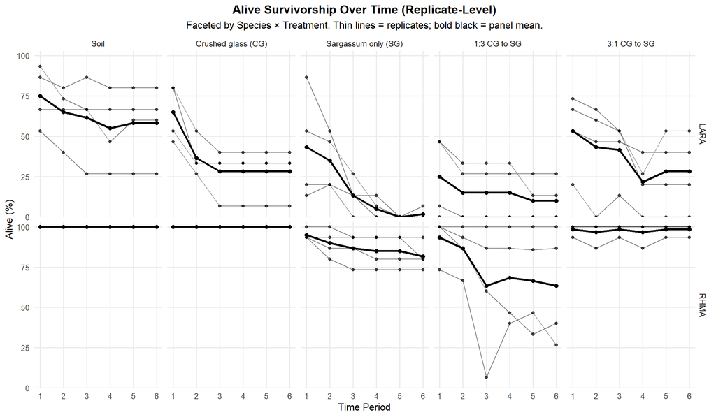

```r
ggplot(
  rep_alive,
  aes(x = Time_Period_num, y = alive_pct, group = Replicate)
) +
  geom_line(alpha = 0.5) +
  geom_point(alpha = 0.7) +
  # Add bold mean line per panel (optional but helpful)
  stat_summary(aes(group = 1), fun = mean, geom = "line", linewidth = 1.2, color = "black") +
  stat_summary(aes(group = 1), fun = mean, geom = "point", size = 2, color = "black") +
  facet_grid(Species ~ Treatment_Name) +
  scale_y_continuous(limits = c(0, 100), expand = expansion(mult = c(0, 0.03))) +
  scale_x_continuous(breaks = sort(unique(rep_alive$Time_Period_num)),
                     labels = sort(unique(rep_alive$Time_Period))) +
  labs(
    x = "Time Period",
    y = "Alive (%)",
    title = "Alive Survivorship Over Time (Replicate-Level)",
    subtitle = "Faceted by Species × Treatment. Thin lines = replicates; bold black = panel mean."
  ) +
  theme_minimal(base_size = 12) +
  theme(
    plot.title = element_text(hjust = 0.5, face = "bold"),
    plot.subtitle = element_text(hjust = 0.5),
    panel.grid.minor = element_blank()
  )
```

## Plot B — Species panels (all treatments together)

Here replicates are still the lines, but **color = Treatment**. Good for comparing treatments within each species directly.

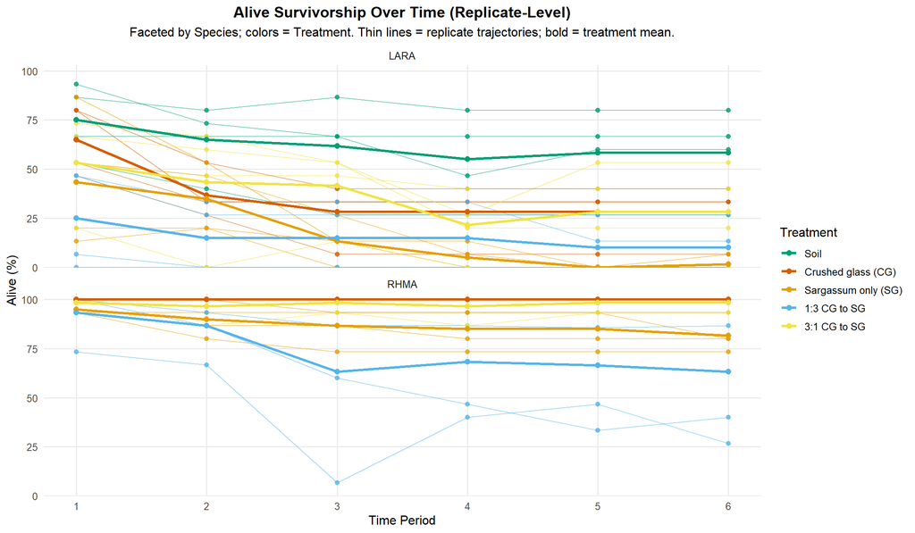

```r
ggplot(
  rep_alive,
  aes(x = Time_Period_num, y = alive_pct, group = interaction(Treatment_Name, Replicate), color = Treatment_Name)
) +
  geom_line(alpha = 0.5) +
  geom_point(alpha = 0.8, size = 1.8) +
  # Mean per treatment over replicates (bold overlay)
  stat_summary(aes(group = Treatment_Name, color = Treatment_Name),
               fun = mean, geom = "line", linewidth = 1.2) +
  stat_summary(aes(group = Treatment_Name, color = Treatment_Name),
               fun = mean, geom = "point", size = 2.2) +
  facet_wrap(~ Species, nrow = 2) +
  scale_color_manual(values = okabe_ito, name = "Treatment") +
  scale_y_continuous(limits = c(0, 100), expand = expansion(mult = c(0, 0.03))) +
  scale_x_continuous(breaks = sort(unique(rep_alive$Time_Period_num)),
                     labels = sort(unique(rep_alive$Time_Period))) +
  labs(
    x = "Time Period",
    y = "Alive (%)",
    title = "Alive Survivorship Over Time (Replicate-Level)",
    subtitle = "Faceted by Species; colors = Treatment. Thin lines = replicate trajectories; bold = treatment mean."
  ) +
  theme_minimal(base_size = 12) +
  theme(
    plot.title = element_text(hjust = 0.5, face = "bold"),
    plot.subtitle = element_text(hjust = 0.5),
    panel.grid.minor = element_blank()
  )
```

## Line chart of treatment means over time

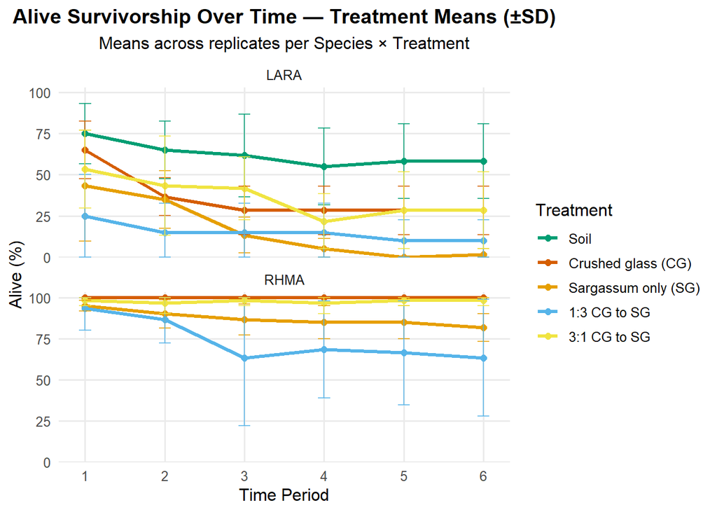

```r
ggplot(alive_summary,
       aes(x = Time_Period_num, y = mean_alive,
           color = Treatment_Name, group = Treatment_Name)) +
  geom_line(linewidth = 1.2) +
  geom_point(size = 2) +
  # Optional error bars (±SD across replicates)
  geom_errorbar(aes(ymin = pmax(mean_alive - sd_alive, 0),
                    ymax = pmin(mean_alive + sd_alive, 100)),
                width = 0.15, alpha = 0.8) +
  facet_wrap(~ Species, nrow = 2) +
  scale_color_manual(values = okabe_ito, name = "Treatment") +
  scale_y_continuous(limits = c(0, 100), expand = expansion(mult = c(0, 0.03))) +
  scale_x_continuous(breaks = sort(unique(alive_summary$Time_Period_num))) +
  labs(
    x = "Time Period", y = "Alive (%)",
    title = "Alive Survivorship Over Time — Treatment Means (±SD)",
    subtitle = "Means across replicates per Species × Treatment"
  ) +
  theme_minimal(base_size = 12) +
  theme(plot.title = element_text(hjust = 0.5, face = "bold"),
        plot.subtitle = element_text(hjust = 0.5),
        panel.grid.minor = element_blank())
```

Stacked area chart of treatment means

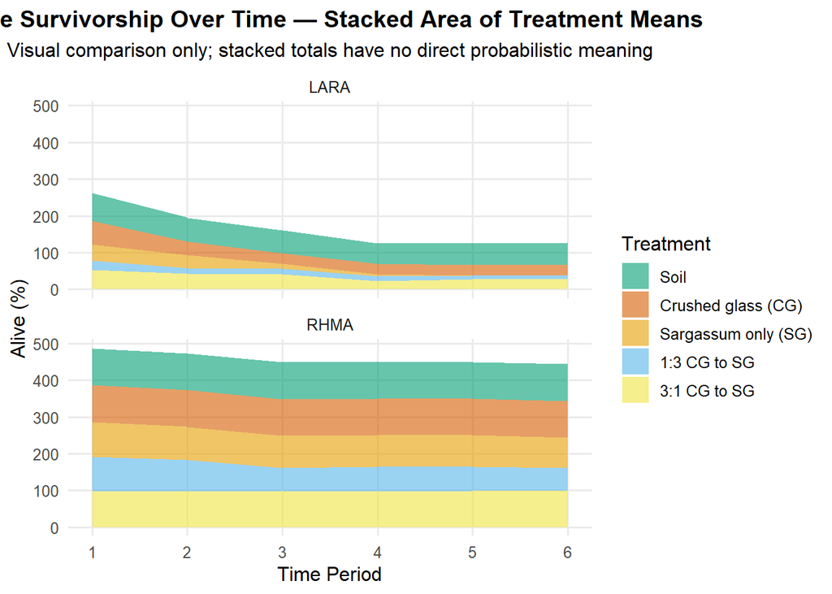

```r
ggplot(alive_summary,
       aes(x = Time_Period_num, y = mean_alive, fill = Treatment_Name)) +
  geom_area(position = "stack", alpha = 0.6) +
  facet_wrap(~ Species, nrow = 2) +
  scale_fill_manual(values = okabe_ito, name = "Treatment") +
  scale_x_continuous(breaks = sort(unique(alive_summary$Time_Period_num))) +
  labs(
    x = "Time Period", y = "Alive (%)",
    title = "Alive Survivorship Over Time — Stacked Area of Treatment Means",
    subtitle = "Visual comparison only; stacked totals have no direct probabilistic meaning"
  ) +
  theme_minimal(base_size = 12) +
  theme(plot.title = element_text(hjust = 0.5, face = "bold"),
        plot.subtitle = element_text(hjust = 0.5),
        panel.grid.minor = element_blank())
```

Prefer an overlapping area look instead of stacking?

Replace position = “stack” with position = “identity” and add alpha (already there) to see treatment areas overlap rather than sum.

## 2A) Line chart of treatment mean alive counts over time (± SD optional)

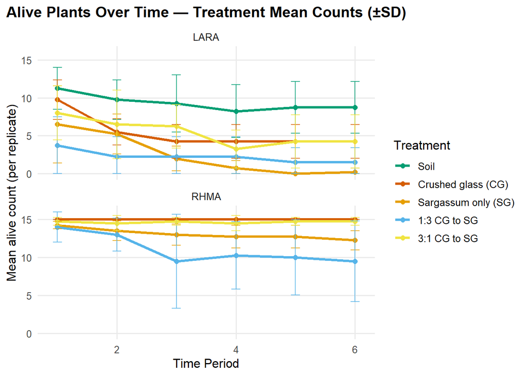

```r
ggplot(alive_count_summary,
       aes(x = Time_Period_num, y = mean_alive_n,
           color = Treatment_Name, group = Treatment_Name)) +
  geom_line(linewidth = 1.2) +
  geom_point(size = 2) +
  # Optional error bars across replicates (comment out if not wanted)
  geom_errorbar(aes(ymin = pmax(mean_alive_n - sd_alive_n, 0),
                    ymax = mean_alive_n + sd_alive_n),
                width = 0.15, alpha = 0.8) +
  facet_wrap(~ Species, nrow = 2) +
  scale_color_manual(values = okabe_ito, name = "Treatment") +
  labs(
    x = "Time Period",
    y = "Mean alive count (per replicate)",
    title = "Alive Plants Over Time — Treatment Mean Counts (±SD)"
  ) +
  theme_minimal(base_size = 12) +
  theme(
    plot.title = element_text(hjust = 0.5, face = "bold"),
    panel.grid.minor = element_blank()
  )
```

## 2B) Stacked area chart of treatment mean alive counts (visual totals)

This stacks mean counts across treatments within a species/time. The stacked height is the sum of treatment means (nice for visual composition, but not a single cohort).

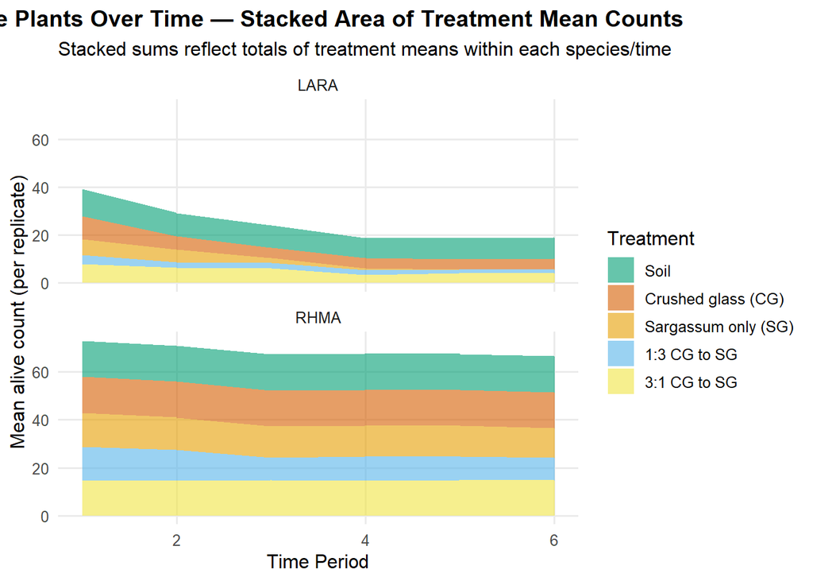

```r
ggplot(alive_count_summary,
       aes(x = Time_Period_num, y = mean_alive_n, fill = Treatment_Name)) +
  geom_area(position = "stack", alpha = 0.6) +
  facet_wrap(~ Species, nrow = 2) +
  scale_fill_manual(values = okabe_ito, name = "Treatment") +
  labs(
    x = "Time Period",
    y = "Mean alive count (per replicate)",
    title = "Alive Plants Over Time — Stacked Area of Treatment Mean Counts",
    subtitle = "Stacked sums reflect totals of treatment means within each species/time"
  ) +
  theme_minimal(base_size = 12) +
  theme(
    plot.title = element_text(hjust = 0.5, face = "bold"),
    panel.grid.minor = element_blank()
  )
```

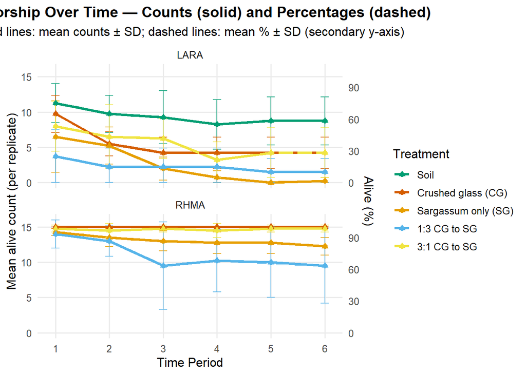

```r
library(ggplot2)

# Suppose max 15 alive individuals corresponds to 100% (adjust if different)
max_count <- 15
max_pct <- 100
scale_factor <- max_pct / max_count  # 100/15 = 6.667

ggplot() +
  # Mean counts line on primary y-axis
  geom_line(data = alive_count_summary,
            aes(x = Time_Period_num,
                y = mean_alive_n,
                color = Treatment_Name,
                group = Treatment_Name),
            linewidth = 1.2) +
  geom_point(data = alive_count_summary,
             aes(x = Time_Period_num,
                 y = mean_alive_n,
                 color = Treatment_Name,
                 group = Treatment_Name),
             size = 2) +
  geom_errorbar(data = alive_count_summary,
                aes(x = Time_Period_num,
                    ymin = pmax(mean_alive_n - sd_alive_n, 0),
                    ymax = mean_alive_n + sd_alive_n,
                    color = Treatment_Name),
                width = 0.15, alpha = 0.8) +

  # Mean % line on secondary scale (scaled down to match counts)
  geom_line(data = alive_summary,
            aes(x = Time_Period_num,
                y = mean_alive / scale_factor,  # convert % to count scale
                color = Treatment_Name,
                group = Treatment_Name),
            linetype = "dashed", linewidth = 1.2) +
  geom_point(data = alive_summary,
             aes(x = Time_Period_num,
                 y = mean_alive / scale_factor,
                 color = Treatment_Name,
                 group = Treatment_Name),
             shape = 17, size = 2) +

  facet_wrap(~ Species, nrow = 2) +
  scale_color_manual(values = okabe_ito, name = "Treatment") +
  scale_x_continuous(breaks = sort(unique(alive_summary$Time_Period_num))) +
  scale_y_continuous(
    name = "Mean alive count (per replicate)",
    # secondary axis: transform back to %
    sec.axis = sec_axis(~ . * scale_factor, name = "Alive (%)")
  ) +
  labs(
    x = "Time Period",
    title = "Survivorship Over Time — Counts (solid) and Percentages (dashed)",
    subtitle = "Solid lines: mean counts ± SD; dashed lines: mean % ± SD (secondary y-axis)"
  ) +
  theme_minimal(base_size = 12) +
  theme(
    plot.title = element_text(hjust = 0.5, face = "bold"),
    plot.subtitle = element_text(hjust = 0.5),
    panel.grid.minor = element_blank()
  )
```

## Build replicate-level summaries & add TP0 baseline

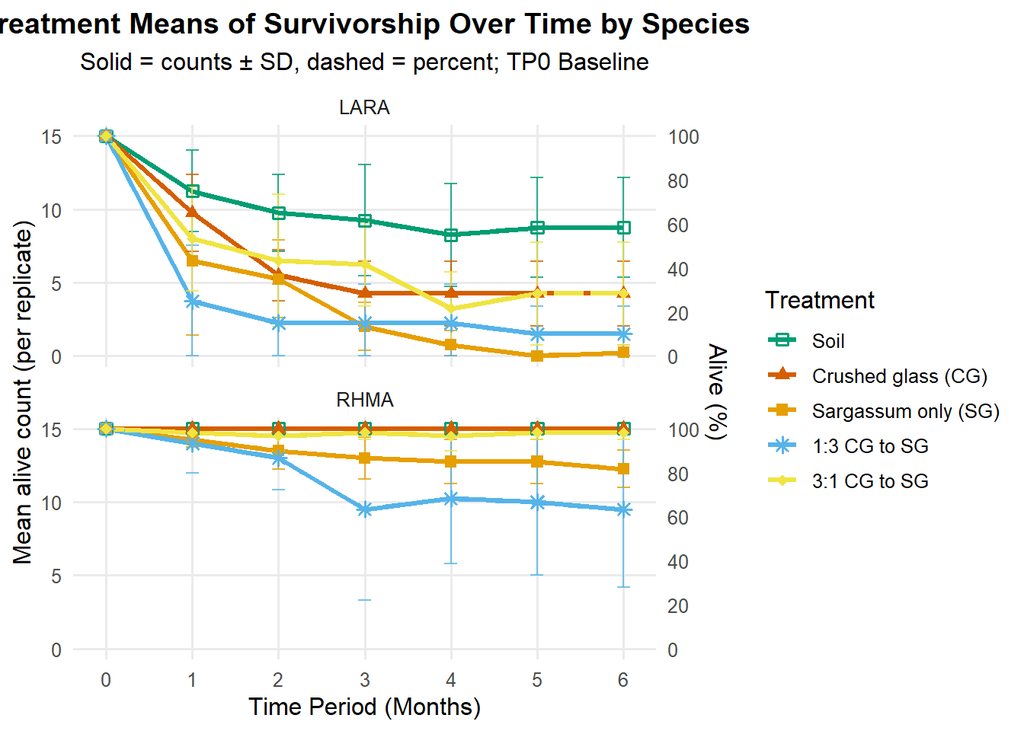

```r
# ---- 1) Build replicate-level summaries & add TP0 baseline ----
library(dplyr)
library(ggplot2)

# A. % Alive per replicate (A only)
rep_alive_pct <- ALLDATA %>%
  group_by(Species, Treatment_Name, Replicate, Time_Period) %>%
  summarise(
    alive_n  = sum(Survivorship == "A", na.rm = TRUE),
    total_n  = n(),
    alive_pct = (alive_n / total_n) * 100,
    .groups = "drop"
  )

tp_is_char <- is.character(rep_alive_pct$Time_Period)

# TP0 baseline: 15/15 alive for *every* replicate
baseline_pct <- rep_alive_pct %>%
  distinct(Species, Treatment_Name, Replicate) %>%
  mutate(
    Time_Period = if (tp_is_char) "TP0" else 0,
    alive_n = 15L,
    total_n = 15L,
    alive_pct = 100
  )

rep_alive_pct_w0 <- bind_rows(rep_alive_pct, baseline_pct) %>%
  mutate(
    Time_Period_num = if (tp_is_char) readr::parse_number(Time_Period) else as.numeric(Time_Period)
  )

alive_summary <- rep_alive_pct_w0 %>%
  group_by(Species, Treatment_Name, Time_Period_num) %>%
  summarise(
    mean_alive = mean(alive_pct, na.rm = TRUE),
    sd_alive   = sd(alive_pct,   na.rm = TRUE),
    .groups = "drop"
  )

# B. Alive counts per replicate (A only)
rep_alive_counts <- ALLDATA %>%
  group_by(Species, Treatment_Name, Replicate, Time_Period) %>%
  summarise(alive_n = sum(Survivorship == "A", na.rm = TRUE), .groups = "drop")

# TP0 baseline: 15 alive per replicate
baseline_counts <- rep_alive_counts %>%
  distinct(Species, Treatment_Name, Replicate) %>%
  mutate(
    Time_Period = if (tp_is_char) "TP0" else 0,
    alive_n     = 15L
  )

rep_alive_counts_w0 <- bind_rows(rep_alive_counts, baseline_counts) %>%
  mutate(
    Time_Period_num = if (tp_is_char) readr::parse_number(Time_Period) else as.numeric(Time_Period)
  )

alive_count_summary <- rep_alive_counts_w0 %>%
  group_by(Species, Treatment_Name, Time_Period_num) %>%
  summarise(
    mean_alive_n = mean(alive_n, na.rm = TRUE),
    sd_alive_n   = sd(alive_n,   na.rm = TRUE),
    .groups = "drop"
  )

# ----- define shapes for each Treatment_Name (match your factor levels) -----
shape_vals <- c(
  "Soil"               = 0, # open square
  "Crushed glass (CG)" = 17, # filled triangle
  "Sargassum only (SG)"= 15, # filled square
  "3:1 CG to SG"       = 18, # filled diamond
  "1:3 CG to SG"       = 8   # asterick
)

# ---- 2) Dual-axis overlay (counts on primary, % on secondary) ----
# Set mapping: 100% alive corresponds to 15 plants/replicate
max_count <- 15
scale_factor <- 100 / max_count  # convert counts<->percent

# For nice x-axis labels if your original Time_Period was like "TP0","TP1",...
x_breaks <- sort(unique(alive_count_summary$Time_Period_num))
x_labels <- if (tp_is_char) paste0("TP", x_breaks) else x_breaks

ggplot() +
  # Primary axis: mean alive counts (solid) ± SD
  geom_line(data = alive_count_summary,
            aes(x = Time_Period_num, y = mean_alive_n,
                color = Treatment_Name, group = Treatment_Name),
            linewidth = 1.2) +
  geom_point(data = alive_count_summary,
             aes(x = Time_Period_num, y = mean_alive_n,
                 color = Treatment_Name, shape = Treatment_Name,
                 group = Treatment_Name),
             size = 2, stroke = 1) +
  geom_errorbar(data = alive_count_summary,
                aes(x = Time_Period_num,
                    ymin = pmax(mean_alive_n - sd_alive_n, 0),
                    ymax = mean_alive_n + sd_alive_n,
                    color = Treatment_Name),
                width = 0.15, alpha = 0.8) +

  # Secondary axis: mean % alive (dashed) mapped onto count scale
  geom_line(data = alive_summary,
            aes(x = Time_Period_num, y = mean_alive / scale_factor,
                color = Treatment_Name, group = Treatment_Name),
            linetype = "dashed", linewidth = 1.2) +
  geom_point(data = alive_summary,
             aes(x = Time_Period_num, y = mean_alive / scale_factor,
                 color = Treatment_Name, shape = Treatment_Name,
                 group = Treatment_Name),
             size = 2, stroke = 1) +

  facet_wrap(~ Species, nrow = 2) +
  scale_color_manual(values = okabe_ito, name = "Treatment") +
  scale_shape_manual(values = shape_vals, name = "Treatment") +
  scale_x_continuous(breaks = x_breaks, labels = x_labels) +
  scale_y_continuous(
    name = "Mean alive count (per replicate)",
    limits = c(0, max_count),
    sec.axis = sec_axis(~ . * scale_factor, name = "Alive (%)", breaks = seq(0, 100, by = 20))
  ) +
  labs(
    x = "Time Period (Months)",
    title = "Treatment Means of Survivorship Over Time by Species",
    subtitle = "Solid = counts ± SD, dashed = percent; TP0 Baseline"
  ) +
  theme_minimal(base_size = 12) +
  theme(
    plot.title = element_text(hjust = 0.5, face = "bold"),
    plot.subtitle = element_text(hjust = 0.5),
    panel.grid.minor = element_blank()
  )
```

### (Optional) Export the replicate-level table

```r
readr::write_csv(rep_alive, "replicate_alive_percent.csv")
```

**Tweaks you can make**

- Want the **Viridis** palette instead? Replace `scale_color_manual(values = okabe_ito)` with:

  ```r
  scale_color_manual(values = viridis_palette)
  ```

- If you’d like **smoothed means** across time, add `geom_smooth(se = FALSE, method = "loess")` (but be cautious with discrete time points).
- If you need **Alive + DY** instead, just change the `summarise()` line to:

  ```r
  alive_n = sum(Survivorship %in% c("A","DY"), na.rm = TRUE)
  ```

  (and re-knit).

## Survivorship Visualizations

```r
# Load necessary libraries
library(dplyr)
library(tidyr)
library(ggplot2)
library(viridis)
library(ggrepel)

# Okabe-Ito colors
okabe_ito <- c("#009E73", "#D55E00", "#E69F00", "#56B4E9", "#F0E442", "#0072B2", "#CC79A7")
# Viridis colors
viridis_palette <- viridis(8)  # Generates a palette with 8 distinct colors

# # Using the same dataset as above
# ALLDATA <- read.csv("Hutchinson_MonthlyMonitoring-MASTER3.csv")

str(ALLDATA)
```

```
## tibble [3,600 × 29] (S3: tbl_df/tbl/data.frame)
##  $ Data_Uploaded  : chr [1:3600] "SH" "SH" "SH" "SH" ...
##  $ Date_Uploaded  : chr [1:3600] "12/08/2024" "12/08/2024" "12/08/2024" "12/08/2024" ...
##  $ Monitored_By   : chr [1:3600] "ZG, SH" "ZG, SH" "ZG, SH" "ZG, SH" ...
##  $ Date_Monitored : chr [1:3600] "12/02/2024" "12/02/2024" "12/02/2024" "12/02/2024" ...
##  $ Location       : num [1:3600] 1 1 1 1 1 1 1 1 1 1 ...
##  $ Replicate      : num [1:3600] 3 3 3 3 3 3 3 3 3 3 ...
##  $ Species        : chr [1:3600] "RHMA" "RHMA" "RHMA" "RHMA" ...
##  $ Treatment      : chr [1:3600] "E" "E" "E" "E" ...
##  $ Prop_ID        : chr [1:3600] "RE-14" "RE-54" "RE-34" "RE-53" ...
##  $ Time_Period    : num [1:3600] 1 1 1 1 1 1 1 1 1 1 ...
##  $ Survivorship   : chr [1:3600] "A" "A" "A" "A" ...
##  $ Condition      : chr [1:3600] "H" "H" "H" "H" ...
##  $ Pests          : chr [1:3600] NA NA NA NA ...
##  $ Leaf_Color     : chr [1:3600] NA "G" NA "G" ...
##  $ RHMA_Height_1  : chr [1:3600] "24.8" "21.2" "19.5" "15.9" ...
##  $ RHMA_Height_2  : chr [1:3600] "15.4" "12" "10" "6.2" ...
##  $ RHMA_Epi_Length: chr [1:3600] "1.4" "4.5" "3.1" "4.4" ...
##  $ LARA_Height_1  : chr [1:3600] NA NA NA NA ...
##  $ LARA_Height_2  : chr [1:3600] NA NA NA NA ...
##  $ Number_Branches: chr [1:3600] "0" "0" "0" "0" ...
##  $ Leaves_Main    : chr [1:3600] "0" "2" "0" "2" ...
##  $ Leaves_Branches: chr [1:3600] "0" "0" "0" "0" ...
##  $ Total_Leaves   : chr [1:3600] "0" "2" "0" "2" ...
##  $ Nodes_Main     : chr [1:3600] "1" "2" "1" "1" ...
##  $ Nodes_Branches : chr [1:3600] "0" "0" "0" "0" ...
##  $ Total_Nodes    : chr [1:3600] "1" "2" "1" "1" ...
##  $ Notes          : chr [1:3600] NA "LCP" "LCP" "LCP" ...
##  $ ...28          : chr [1:3600] NA NA NA NA ...
##  $ Treatment_Name : Factor w/ 5 levels "Soil","Crushed glass (CG)",..: 4 4 4 4 4 4 4 4 4 4 ...
```

```r
survivorship_summary <- ALLDATA %>%
  group_by(Species, Treatment_Name, Time_Period, Survivorship) %>%
  summarise(Count = n(), .groups = 'drop') %>%
  mutate(Status = case_when(
    Survivorship == "A" ~ "Alive",
    Survivorship == "DY" ~ "Dying",
    Survivorship == "D" ~ "Dead"))%>%
  mutate(
    Time_Period = as.factor(Time_Period),   # Ensure Time_Period is treated as a factor
    Treatment = as.factor(Treatment_Name))       # Ensure Treatment is treated as a factor


# Print the summary table
print(survivorship_summary)
```

```
## # A tibble: 134 × 7
##    Species Treatment_Name Time_Period Survivorship Count Status Treatment
##    <chr>   <fct>          <fct>       <chr>        <int> <chr>  <fct>
##  1 LARA    Soil           1           A               45 Alive  Soil
##  2 LARA    Soil           1           D               13 Dead   Soil
##  3 LARA    Soil           1           DY               2 Dying  Soil
##  4 LARA    Soil           2           A               39 Alive  Soil
##  5 LARA    Soil           2           D               19 Dead   Soil
##  6 LARA    Soil           2           DY               2 Dying  Soil
##  7 LARA    Soil           3           A               37 Alive  Soil
##  8 LARA    Soil           3           D               22 Dead   Soil
##  9 LARA    Soil           3           DY               1 Dying  Soil
## 10 LARA    Soil           4           A               33 Alive  Soil
## # ℹ 124 more rows
```

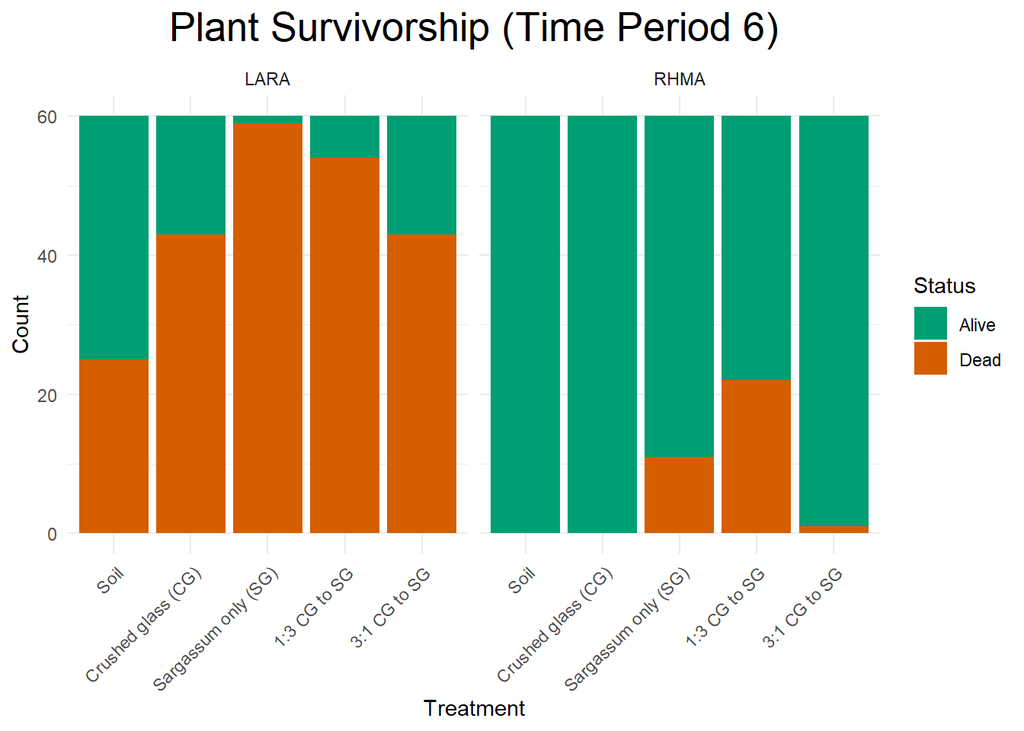

```r
##I'm using the survivorship_summary dataframe to make the bar charts and the survivorship_summary2 dataframe to make the pie charts.

# Filter for Time_Period == 6
survivorship_summary_tp6 <- survivorship_summary %>%
  filter(Time_Period == 6)

# Stacked bar plot
ggplot(survivorship_summary_tp6, aes(x = Treatment_Name, y = Count, fill = Status)) +
  geom_bar(stat = "identity") +
  facet_wrap(~ Species, ncol = 2) +
  labs(title = "Plant Survivorship (Time Period 6)",
       x = "Treatment", y = "Count") +
  theme_minimal() +
  theme(axis.text.x = element_text(angle = 45, hjust = 1),
        plot.title = element_text(hjust = 0.5, size = 20)) +
  scale_fill_manual(values = okabe_ito)
```

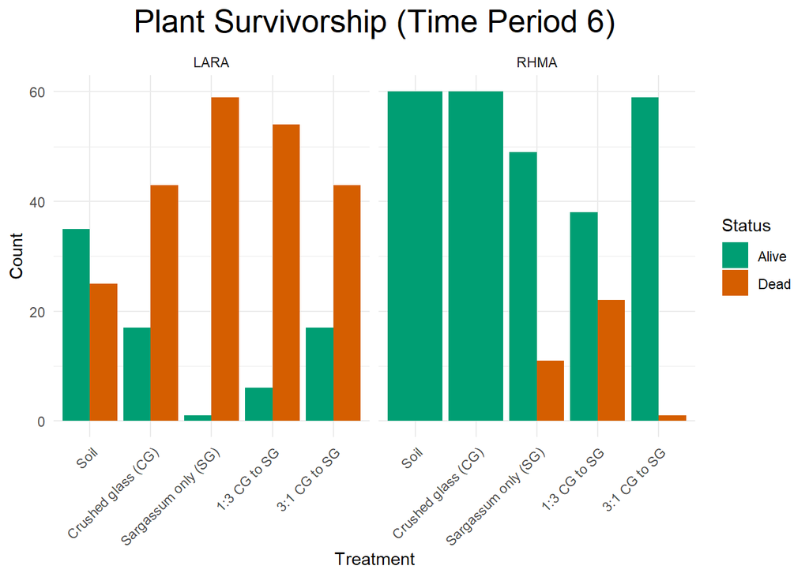

```r
# Save the plot to a file
# ggsave("final_survivorship_stackedbarchart.png", width = 10, height = 6)

# Side-by-side bar plot
ggplot(survivorship_summary_tp6, aes(x = Treatment_Name, y = Count, fill = Status)) +
  geom_bar(stat = "identity", position = position_dodge()) +
  facet_wrap(~ Species, ncol = 2) +
  labs(title = "Plant Survivorship (Time Period 6)",
       x = "Treatment", y = "Count") +
  theme_minimal() +
  theme(axis.text.x = element_text(angle = 45, hjust = 1),
        plot.title = element_text(hjust = 0.5, size = 20)) +
  scale_fill_manual(values = okabe_ito)
```

```r
# Save the plot to a file
# ggsave("final_survivorship_sidebarchart.png", width = 10, height = 6)
```

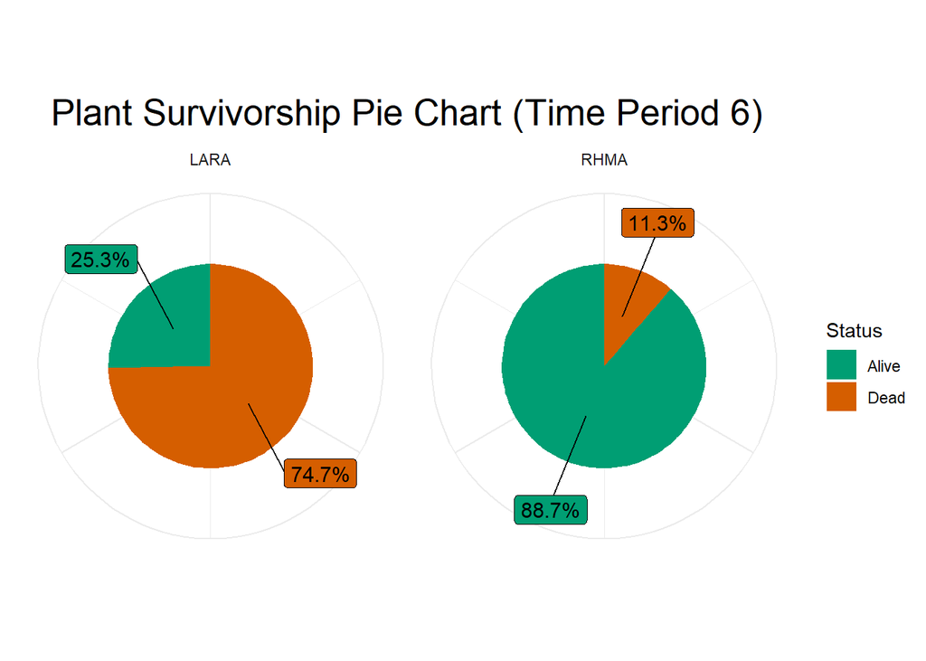

```r
#Create 2nd dataframe for the pie charts but without Treatment
survivorship_summary2 <- ALLDATA %>%
  group_by(Species, Time_Period, Survivorship) %>%
  summarise(Count = n(), .groups = 'drop') %>%
  mutate(Status = case_when(
    Survivorship == "A" ~ "Alive",
    Survivorship == "DY" ~ "Dying",
    Survivorship == "D" ~ "Dead"))%>%
  mutate(
    Time_Period = as.factor(Time_Period))   # Ensure Time_Period is treated as a factor


# Calculate percentages and positions for labels
survivorship_summary2 <- survivorship_summary2 %>%
  group_by(Time_Period, Species) %>%
  mutate(Percentage = Count / sum(Count) * 100,
         csum = rev(cumsum(rev(Count))),
         pos = Count / 2 + lead(csum, 1),
         pos = if_else(is.na(pos), Count / 2, pos))



# Filter for Time_Period == 6
survivorship_summary2_tp6 <- survivorship_summary2 %>%
  filter(Time_Period == 6)

# Pie chart
ggplot(survivorship_summary2_tp6, aes(x = "", y = Count, fill = Status)) +
  geom_bar(stat = "identity", width = 1) +
  coord_polar(theta = "y") +
  facet_wrap(~ Species, ncol = 2) +
  labs(title = "Plant Survivorship Pie Chart (Time Period 6)",
       x = NULL, y = NULL) +
  theme_minimal() +
  theme(axis.text.x = element_blank(),
        plot.title = element_text(hjust = 0.5, size = 20)) +
  scale_fill_manual(values = okabe_ito) +
  geom_label_repel(data = survivorship_summary2_tp6,
                   aes(y = pos, label = paste0(round(Percentage, 1), "%")),
                   size = 4,
                   nudge_x = 1,
                   show.legend = FALSE)
```

```r
# Save the plot to a file
# ggsave("final_survivorship_piechart.png", width = 10, height = 6)
```

```r
# Summarize the data
survivorship_summary3 <- ALLDATA %>%
  group_by(Treatment_Name, Time_Period, Species) %>%  # Group by treatment (with new names), time period, and Species
  mutate(
    Time_Period = as.factor(Time_Period) # Ensure Time_Period is treated as a factor
  ) %>%
  summarise(
    Total = n(),  # Total number of plants in that group
    Alive = sum(Survivorship == "A", na.rm = TRUE),  # Number of plants alive
    Dying = sum(Survivorship == "DY", na.rm = TRUE),  # Number of plants dying
    Dead = sum(Survivorship == "D", na.rm = TRUE),  # Number of plants dead
    Survival_Rate = Alive / Total * 100 + Dying/Total *100,  # Calculate survival rate
    .groups = 'drop'
  )

# Print the summary table
print(survivorship_summary3)
```

```
## # A tibble: 60 × 8
##    Treatment_Name Time_Period Species Total Alive Dying  Dead Survival_Rate
##    <fct>          <fct>       <chr>   <int> <int> <int> <int>         <dbl>
##  1 Soil           1           LARA       60    45     2    13          78.3
##  2 Soil           1           RHMA       60    60     0     0         100
##  3 Soil           2           LARA       60    39     2    19          68.3
##  4 Soil           2           RHMA       60    60     0     0         100
##  5 Soil           3           LARA       60    37     1    22          63.3
##  6 Soil           3           RHMA       60    60     0     0         100
##  7 Soil           4           LARA       60    33     3    24          60
##  8 Soil           4           RHMA       60    60     0     0         100
##  9 Soil           5           LARA       60    35     0    25          58.3
## 10 Soil           5           RHMA       60    60     0     0         100
## # ℹ 50 more rows
```

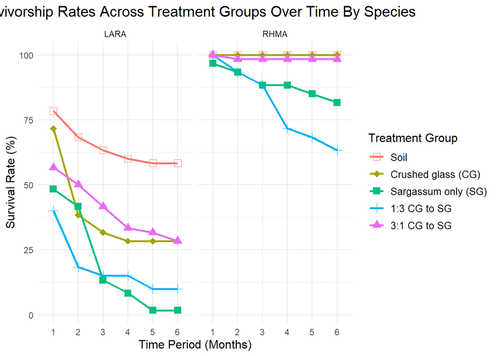

```r
# Create a line graph of survivorship rates over time for each treatment
ggplot(survivorship_summary3, aes(x = Time_Period, y = Survival_Rate, group = Treatment_Name, color = Treatment_Name, shape = Treatment_Name)) +
  geom_line(linewidth = 1) +  # Add lines for each treatment
  geom_point(size = 3) +  # Add points to mark data points
  facet_wrap(~ Species) + # Separate plots by Species
  labs(
    title = "Survivorship Rates Across Treatment Groups Over Time By Species",
    x = "Time Period (Months)",
    y = "Survival Rate (%)",
    color = "Treatment Group"  # Legend title
  ) +
  scale_color_discrete(name = "Treatment Group") +
  scale_shape_manual(name = "Treatment Group",
                     values = c(0, 18, 15, 3, 17)) + #Add specific shapes in a high contrast order
  theme_minimal() +  # Use a minimal theme for cleaner look
  theme(
    plot.title = element_text(hjust = 0.5, size = 15),  # Center and enlarge title
    axis.title = element_text(size = 12),  # Enlarge axis titles
    legend.title = element_text(size = 12),  # Enlarge legend title
    legend.text = element_text(size = 10)  # Enlarge legend text
  )
```

```r
# # Optional: Save the plot to a file
# ggsave("final_survivorship_rates_plot_species.png", width = 8, height = 6, units = "in")

# Filter for Time_Period == 6
survivorship_summary3_tp6 <- survivorship_summary3 %>%
  filter(Time_Period == 6)

str(survivorship_summary3_tp6)
```

```
## tibble [10 × 8] (S3: tbl_df/tbl/data.frame)
##  $ Treatment_Name: Factor w/ 5 levels "Soil","Crushed glass (CG)",..: 1 1 2 2 3 3 4 4 5 5
##  $ Time_Period   : Factor w/ 6 levels "1","2","3","4",..: 6 6 6 6 6 6 6 6 6 6
##  $ Species       : chr [1:10] "LARA" "RHMA" "LARA" "RHMA" ...
##  $ Total         : int [1:10] 60 60 60 60 60 60 60 60 60 60
##  $ Alive         : int [1:10] 35 60 17 60 1 49 6 38 17 59
##  $ Dying         : int [1:10] 0 0 0 0 0 0 0 0 0 0
##  $ Dead          : int [1:10] 25 0 43 0 59 11 54 22 43 1
##  $ Survival_Rate : num [1:10] 58.33 100 28.33 100 1.67 ...
```

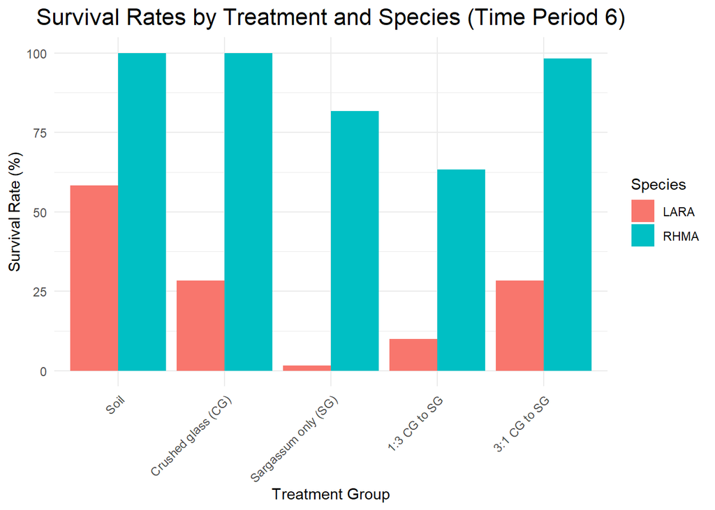

```r
ggplot(survivorship_summary3_tp6, aes(x = Treatment_Name, y = Survival_Rate, fill = Species)) +
  geom_bar(stat = "identity", position = position_dodge()) +
  labs(
    title = "Survival Rates by Treatment and Species (Time Period 6)",
    x = "Treatment Group",
    y = "Survival Rate (%)",
    fill = "Species"
  ) +
  theme_minimal() +
  theme(
    plot.title = element_text(hjust = 0.5, size = 16),
    axis.text.x = element_text(angle = 45, hjust = 1)
  )
```

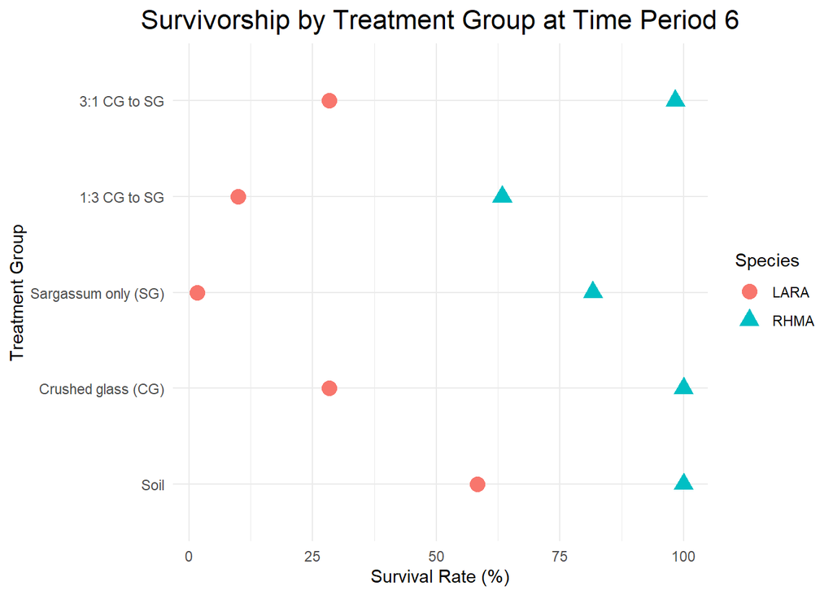

```r
ggplot(survivorship_summary3_tp6, aes(x = Survival_Rate, y = Treatment_Name, color = Species, shape = Species)) +
  geom_point(size = 4) +
  labs(
    title = "Survivorship by Treatment Group at Time Period 6",
    x = "Survival Rate (%)",
    y = "Treatment Group",
    color = "Species",
    shape = "Species"
  ) +
  theme_minimal() +
  theme(
    plot.title = element_text(hjust = 0.5, size = 16)
  )
```

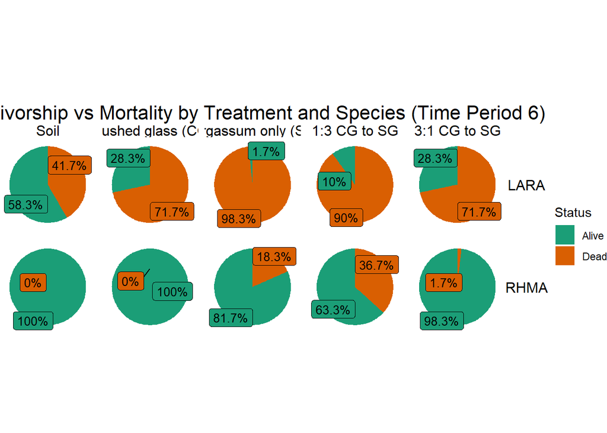

```r
#Step 1: Create Long Format with Alive + Dead (for Time_Period 6 only)

# Create long format: Alive vs Dead only
survivorship_pie_tp6 <- survivorship_summary3_tp6 %>%
  select(Species, Treatment_Name, Alive, Dead) %>%
  pivot_longer(cols = c(Alive, Dead),
               names_to = "Status",
               values_to = "Count")

#Step 2: Calculate Total and Percentages for Pie Labels

# Calculate total per Species and Treatment, then % per Status
survivorship_pie_tp6 <- survivorship_pie_tp6 %>%
  group_by(Species, Treatment_Name) %>%
  mutate(
    Total = sum(Count),
    Percentage = Count / Total * 100,
    csum = rev(cumsum(rev(Count))),
    pos = Count / 2 + lead(csum, 1),
    pos = if_else(is.na(pos), Count / 2, pos)
  ) %>%
  ungroup()


#Step 3: Plot Pie Charts for Survivorship vs Mortality
ggplot(survivorship_pie_tp6, aes(x = "", y = Count, fill = Status)) +
  geom_bar(stat = "identity", width = 1) +
  coord_polar(theta = "y") +
  facet_grid(Species ~ Treatment_Name) +
  geom_label_repel(
    aes(y = pos, label = paste0(round(Percentage, 1), "%")),
    size = 3.5,
    show.legend = FALSE
  ) +
  labs(
    title = "Survivorship vs Mortality by Treatment and Species (Time Period 6)",
    x = NULL, y = NULL
  ) +
  theme_void() +
  theme(
    plot.title = element_text(hjust = 0.5, size = 16),
    strip.text = element_text(size = 12)
  ) +
  scale_fill_manual(values = c("Alive" = "#1b9e77", "Dead" = "#d95f02"))
```

## Survivorship Analyses (Statistics)

```r
##This R script aims to import and visualize survivorship data for red and white mangroves grown in 5 different treatments over a 6 month period.

# Load required libraries
library(ggrepel)
library(emmeans)
```

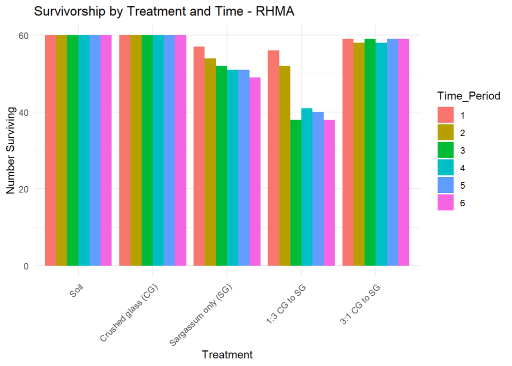

```r
library(lme4)


# Step 1: Clean and Prepare Data
survivors_clean <- ALLDATA %>%
  mutate(
    Surv_Bin = ifelse(Survivorship %in% c("A"), 1, 0),
    Treatment = case_when(
      Treatment == "A" ~ "Soil",
      Treatment == "B" ~ "Crushed glass (CG)",
      Treatment == "C" ~ "Sargassum only (SG)",
      Treatment == "D" ~ "3:1 CG to SG",
      Treatment == "E" ~ "1:3 CG to SG",
      TRUE ~ as.character(Treatment)
    ),
    Treatment = factor(Treatment, levels = c("Soil", "Crushed glass (CG)", "Sargassum only (SG)", "1:3 CG to SG", "3:1 CG to SG")), #order the treatments based on most SG to least SG for visualizations
    Time_Period = factor(Time_Period, levels = c("1", "2", "3", "4", "5", "6")),
    Species = factor(Species)
  )

# Step 2: Subset by Species
RHMA <- survivors_clean %>% filter(Species == "RHMA")
LARA <- survivors_clean %>% filter(Species == "LARA")

# Step 3: Summarize and Visualize Raw Survivorship
plot_survivorship <- function(data, species_name) {
  data %>%
    group_by(Treatment, Time_Period) %>%
    summarise(ALLDATA = sum(Surv_Bin), .groups = 'drop') %>%
    ggplot(aes(x = Treatment, y = ALLDATA, fill = Time_Period)) +
    geom_bar(stat = "identity", position = position_dodge()) +
    labs(title = paste("Survivorship by Treatment and Time -", species_name),
         y = "Number Surviving") +
    theme_minimal() +
    theme(axis.text.x = element_text(angle = 45, hjust = 1))
}

plot_survivorship(RHMA, "RHMA")
```

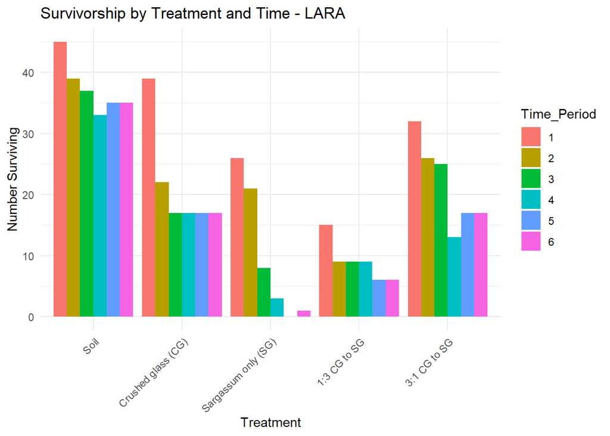

```r
plot_survivorship(LARA, "LARA")
```

```r
# Step 4: Fit Logistic Regression (GLM)
glm_LARA <- glm(Surv_Bin ~ Treatment * Time_Period, data = LARA, family = binomial())
glm_RHMA <- glm(Surv_Bin ~ Treatment * Time_Period, data = RHMA, family = binomial())

summary(glm_LARA)
```

```
##
## Call:
## glm(formula = Surv_Bin ~ Treatment * Time_Period, family = binomial(),
##     data = LARA)
##
## Coefficients:
##                                            Estimate Std. Error z value Pr(>|z|)
## (Intercept)                                 1.09861    0.29814   3.685 0.000229
## TreatmentCrushed glass (CG)                -0.47957    0.40268  -1.191 0.233669
## TreatmentSargassum only (SG)               -1.36688    0.39593  -3.452 0.000556
## Treatment1:3 CG to SG                      -2.19722    0.42164  -5.211 1.88e-07
## Treatment3:1 CG to SG                      -0.96508    0.39478  -2.445 0.014502
## Time_Period2                               -0.47957    0.40268  -1.191 0.233669
## Time_Period3                               -0.62319    0.39924  -1.561 0.118540
## Time_Period4                               -0.89794    0.39526  -2.272 0.023099
## Time_Period5                               -0.76214    0.39681  -1.921 0.054775
## Time_Period6                               -0.76214    0.39681  -1.921 0.054775
## TreatmentCrushed glass (CG):Time_Period2   -0.68601    0.55424  -1.238 0.215807
## TreatmentSargassum only (SG):Time_Period2   0.12880    0.55071   0.234 0.815081
## Treatment1:3 CG to SG:Time_Period2         -0.15642    0.61786  -0.253 0.800148
## Treatment3:1 CG to SG:Time_Period2          0.07778    0.54496   0.143 0.886511
## TreatmentCrushed glass (CG):Time_Period3   -0.92384    0.56101  -1.647 0.099612
## TreatmentSargassum only (SG):Time_Period3  -0.98035    0.60951  -1.608 0.107741
## Treatment1:3 CG to SG:Time_Period3         -0.01280    0.61563  -0.021 0.983412
## Treatment3:1 CG to SG:Time_Period3          0.15318    0.54307   0.282 0.777890
## TreatmentCrushed glass (CG):Time_Period4   -0.64908    0.55818  -1.163 0.244890
## TreatmentSargassum only (SG):Time_Period4  -1.77823    0.75827  -2.345 0.019022
## Treatment1:3 CG to SG:Time_Period4          0.26195    0.61306   0.427 0.669168
## Treatment3:1 CG to SG:Time_Period4         -0.52079    0.56692  -0.919 0.358287
## TreatmentCrushed glass (CG):Time_Period5   -0.78489    0.55929  -1.403 0.160505
## TreatmentSargassum only (SG):Time_Period5 -15.53566  309.78025  -0.050 0.960002
## Treatment1:3 CG to SG:Time_Period5         -0.33647    0.65691  -0.512 0.608509
## Treatment3:1 CG to SG:Time_Period5         -0.29938    0.55363  -0.541 0.588675
## TreatmentCrushed glass (CG):Time_Period6   -0.78489    0.55929  -1.403 0.160505
## TreatmentSargassum only (SG):Time_Period6  -3.04713    1.11458  -2.734 0.006259
## Treatment1:3 CG to SG:Time_Period6         -0.33647    0.65691  -0.512 0.608509
## Treatment3:1 CG to SG:Time_Period6         -0.29938    0.55363  -0.541 0.588675
##
## (Intercept)                               ***
## TreatmentCrushed glass (CG)
```

[output cut: 23 more lines]

```
## Treatment3:1 CG to SG:Time_Period5
## TreatmentCrushed glass (CG):Time_Period6
## TreatmentSargassum only (SG):Time_Period6 **
## Treatment1:3 CG to SG:Time_Period6
## Treatment3:1 CG to SG:Time_Period6
## ---
## Signif. codes:  0 '***' 0.001 '**' 0.01 '*' 0.05 '.' 0.1 ' ' 1
##
## (Dispersion parameter for binomial family taken to be 1)
##
##     Null deviance: 2285.9  on 1799  degrees of freedom
## Residual deviance: 1904.2  on 1770  degrees of freedom
## AIC: 1964.2
##
## Number of Fisher Scoring iterations: 15
```

```r
summary(glm_RHMA)
```

```
##
## Call:
## glm(formula = Surv_Bin ~ Treatment * Time_Period, family = binomial(),
##     data = RHMA)
##
## Coefficients:
##                                             Estimate Std. Error z value
## (Intercept)                                2.057e+01  2.289e+03   0.009
## TreatmentCrushed glass (CG)               -2.323e-07  3.237e+03   0.000
## TreatmentSargassum only (SG)              -1.762e+01  2.289e+03  -0.008
## Treatment1:3 CG to SG                     -1.793e+01  2.289e+03  -0.008
## Treatment3:1 CG to SG                     -1.649e+01  2.289e+03  -0.007
## Time_Period2                              -3.265e-07  3.237e+03   0.000
## Time_Period3                              -2.357e-07  3.237e+03   0.000
## Time_Period4                              -3.583e-07  3.237e+03   0.000
## Time_Period5                              -3.021e-07  3.237e+03   0.000
## Time_Period6                              -2.765e-07  3.237e+03   0.000
## TreatmentCrushed glass (CG):Time_Period2   3.265e-07  4.578e+03   0.000
## TreatmentSargassum only (SG):Time_Period2 -7.472e-01  3.237e+03   0.000
## Treatment1:3 CG to SG:Time_Period2        -7.673e-01  3.237e+03   0.000
## Treatment3:1 CG to SG:Time_Period2        -7.102e-01  3.237e+03   0.000
## TreatmentCrushed glass (CG):Time_Period3   2.541e-07  4.578e+03   0.000
## TreatmentSargassum only (SG):Time_Period3 -1.073e+00  3.237e+03   0.000
## Treatment1:3 CG to SG:Time_Period3        -2.093e+00  3.237e+03  -0.001
## Treatment3:1 CG to SG:Time_Period3         2.357e-07  3.237e+03   0.000
## TreatmentCrushed glass (CG):Time_Period4   3.740e-07  4.578e+03   0.000
## TreatmentSargassum only (SG):Time_Period4 -1.210e+00  3.237e+03   0.000
## Treatment1:3 CG to SG:Time_Period4        -1.870e+00  3.237e+03  -0.001
## Treatment3:1 CG to SG:Time_Period4        -7.102e-01  3.237e+03   0.000
## TreatmentCrushed glass (CG):Time_Period5   3.180e-07  4.578e+03   0.000
## TreatmentSargassum only (SG):Time_Period5 -1.210e+00  3.237e+03   0.000
## Treatment1:3 CG to SG:Time_Period5        -1.946e+00  3.237e+03  -0.001
## Treatment3:1 CG to SG:Time_Period5         3.021e-07  3.237e+03   0.000
## TreatmentCrushed glass (CG):Time_Period6   2.923e-07  4.578e+03   0.000
## TreatmentSargassum only (SG):Time_Period6 -1.451e+00  3.237e+03   0.000
## Treatment1:3 CG to SG:Time_Period6        -2.093e+00  3.237e+03  -0.001
## Treatment3:1 CG to SG:Time_Period6         2.765e-07  3.237e+03   0.000
##                                           Pr(>|z|)
## (Intercept)                                  0.993
## TreatmentCrushed glass (CG)                  1.000
```

[output cut: 21 more lines]

```
## TreatmentSargassum only (SG):Time_Period5    1.000
## Treatment1:3 CG to SG:Time_Period5           1.000
## Treatment3:1 CG to SG:Time_Period5           1.000
## TreatmentCrushed glass (CG):Time_Period6     1.000
## TreatmentSargassum only (SG):Time_Period6    1.000
## Treatment1:3 CG to SG:Time_Period6           0.999
## Treatment3:1 CG to SG:Time_Period6           1.000
##
## (Dispersion parameter for binomial family taken to be 1)
##
##     Null deviance: 1027.81  on 1799  degrees of freedom
## Residual deviance:  729.87  on 1770  degrees of freedom
## AIC: 789.87
##
## Number of Fisher Scoring iterations: 19
```

```r
# Step 5: Estimated Marginal Means and Plotting (LARA example)
emm_LARA <- emmeans(glm_LARA, pairwise ~ Treatment, type = "response")
```

```
## NOTE: Results may be misleading due to involvement in interactions
```

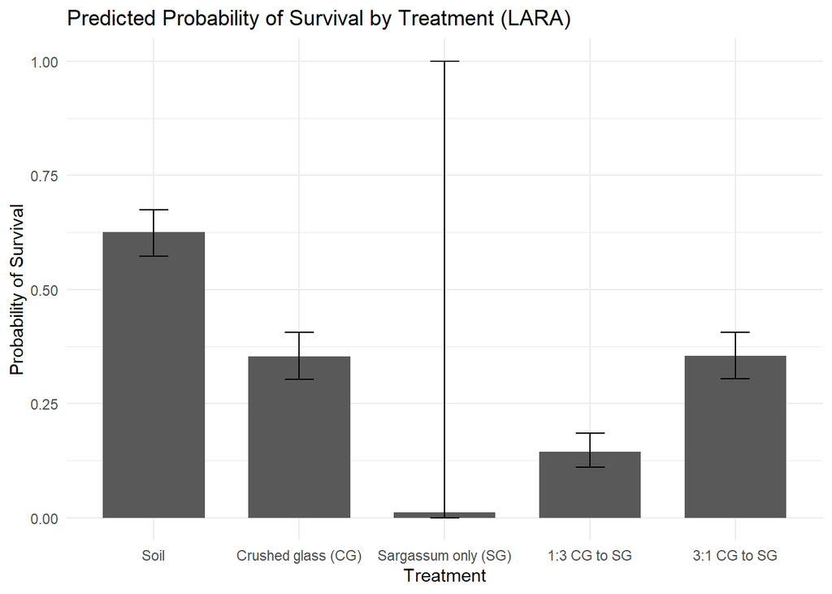

```r
pred_LARA <- as.data.frame(emm_LARA$emmeans)

ggplot(pred_LARA, aes(x = Treatment, y = prob)) +
  geom_bar(stat = "identity", position = position_dodge(width = 0.8), width = 0.7) +
  geom_errorbar(aes(ymin = asymp.LCL, ymax = asymp.UCL),
                position = position_dodge(width = 0.8), width = 0.2) +
  labs(title = "Predicted Probability of Survival by Treatment (LARA)",
       x = "Treatment", y = "Probability of Survival") +
  theme_minimal()
```

```r
library(lme4)

# Step 6: Fit GLMMs with Random Effect of Replicate
RHMA$Time_Period <- factor(RHMA$Time_Period, levels = 1:6)
LARA$Time_Period <- factor(LARA$Time_Period, levels = 1:6)

glmm_LARA <- glmer(Surv_Bin ~ Treatment * Time_Period + (1 | Replicate), data = LARA, family = binomial())
glmm_RHMA <- glmer(Surv_Bin ~ Treatment * Time_Period + (1 | Replicate), data = RHMA, family = binomial())
summary(glmm_LARA)
```

```
## Generalized linear mixed model fit by maximum likelihood (Laplace
##   Approximation) [glmerMod]
##  Family: binomial  ( logit )
## Formula: Surv_Bin ~ Treatment * Time_Period + (1 | Replicate)
##    Data: LARA
##
##       AIC       BIC    logLik -2*log(L)  df.resid
##    1902.3    2072.7    -920.2    1840.3      1769
##
## Scaled residuals:
##     Min      1Q  Median      3Q     Max
## -2.3492 -0.6598 -0.3510  0.7100  6.8896
##
## Random effects:
##  Groups    Name        Variance Std.Dev.
##  Replicate (Intercept) 0.2576   0.5075
## Number of obs: 1800, groups:  Replicate, 4
##
## Fixed effects:
##                                             Estimate Std. Error z value
## (Intercept)                                 1.160784   0.397597   2.920
## TreatmentCrushed glass (CG)                -0.506879   0.413701  -1.225
## TreatmentSargassum only (SG)               -1.450214   0.406991  -3.563
## Treatment1:3 CG to SG                      -2.323900   0.432217  -5.377
## Treatment3:1 CG to SG                      -1.023185   0.405889  -2.521
## Time_Period2                               -0.506909   0.413700  -1.225
## Time_Period3                               -0.659470   0.410305  -1.607
## Time_Period4                               -0.951933   0.406360  -2.343
## Time_Period5                               -0.807343   0.407901  -1.979
## Time_Period6                               -0.807157   0.407904  -1.979
## TreatmentCrushed glass (CG):Time_Period2   -0.730930   0.569535  -1.283
## TreatmentSargassum only (SG):Time_Period2   0.136002   0.565603   0.240
## Treatment1:3 CG to SG:Time_Period2         -0.150864   0.630848  -0.239
## Treatment3:1 CG to SG:Time_Period2          0.079859   0.560313   0.143
## TreatmentCrushed glass (CG):Time_Period3   -0.979299   0.575997  -1.700
## TreatmentSargassum only (SG):Time_Period3  -1.012719   0.622887  -1.626
## Treatment1:3 CG to SG:Time_Period3          0.001711   0.628612   0.003
## Treatment3:1 CG to SG:Time_Period3          0.160141   0.558384   0.287
## TreatmentCrushed glass (CG):Time_Period4   -0.686791   0.573050  -1.198
## TreatmentSargassum only (SG):Time_Period4  -1.810169   0.769548  -2.352
```

[output cut: 28 more lines]

```
## Treatment3:1 CG to SG:Time_Period3        0.774270
## TreatmentCrushed glass (CG):Time_Period4  0.230729
## TreatmentSargassum only (SG):Time_Period4 0.018660 *
## Treatment1:3 CG to SG:Time_Period4        0.638435
## Treatment3:1 CG to SG:Time_Period4        0.350490
## TreatmentCrushed glass (CG):Time_Period5  0.147681
## TreatmentSargassum only (SG):Time_Period5 0.981311
## Treatment1:3 CG to SG:Time_Period5        0.628721
## Treatment3:1 CG to SG:Time_Period5        0.579476
## TreatmentCrushed glass (CG):Time_Period6  0.147568
## TreatmentSargassum only (SG):Time_Period6 0.005891 **
## Treatment1:3 CG to SG:Time_Period6        0.628514
## Treatment3:1 CG to SG:Time_Period6        0.579036
## ---
## Signif. codes:  0 '***' 0.001 '**' 0.01 '*' 0.05 '.' 0.1 ' ' 1
```

```
##
## Correlation matrix not shown by default, as p = 30 > 12.
## Use print(x, correlation=TRUE)  or
##     vcov(x)        if you need it
```

```
## optimizer (Nelder_Mead) convergence code: 0 (OK)
## unable to evaluate scaled gradient
## Model failed to converge: degenerate  Hessian with 1 negative eigenvalues
```